```python
import numpy as np
import matplotlib.pyplot as plt
import os
import glob
from pyntcloud import PyntCloud
import plyfile as ply
import sys
import DracoPy
import shutil
import pandas as pd
```

# Compression of labeled Point Clouds

Given a set of point clouds that represent scenes structured upon different objects, the task of our project is to study systems that performs information compression, encoding each class. Such strategy is proposed in comparison of the classic direct compression of the point clouds as a whole.

# Dataset: SELMA [1]

We consider SELMA [1], a dataset for semantic segmentation that contains more than 30K unique waypoints acquired from 24 different sensors including RGB, depth, semantic cameras and LiDARs.

### LIDARs

In particular, our analysis focuses on the LiDAR data, which are collected by means of 3 semantic LiDARs, each with 64 vertical channels, generating 100000 points per second, with a range of 100 meters. Point clouds are saved in PLY format. LIDARS are placed on a vehicle as follows:

- *1 top LiDARs (TOP)*, with a 360° view of the scene.
- *2 front-lateral LiDARs* placed on the headlights with 270° of aperture, overlapping in the front of the ego vehicle.

The positioning of the LiDARs is shown in the following figure:

[figure not shown]

### Merging

We merge the point clouds from the 3 different LiDARs perspectives, in order to have a single point cloud with all the three LiDARs cumulative information. That is going to allow us to build a compression startegy based on the manipulation of a single, denser, point cloud. This will be useful both to make the procedure more straight forward and to give us a starting point with more redundant information we can exploit for our study.

```python
import open3d as o3d
from tqdm import tqdm

def combine (
    main_dir,
    Nfiles=100,
    outdir='dataset_final',
    ):
    import glob
    # find all scan codes
    left_lidar_codes = glob.glob(os.path.join(main_dir, 'LIDAR_FRONT_LEFT', '*.ply'))
    left_lidar_codes = [f.split('/')[-1].split('.')[0] for f in left_lidar_codes]
    left_lidar_codes.sort()
    print (f"Number of left lidar codes: {len(left_lidar_codes)}")

    right_lidar_codes = glob.glob(os.path.join(main_dir, 'LIDAR_FRONT_RIGHT', '*.ply'))
    right_lidar_codes = [f.split('/')[-1].split('.')[0] for f in right_lidar_codes]
    right_lidar_codes.sort()
    print (f"Number of left lidar codes: {len(left_lidar_codes)}")

    top_lidar_codes = glob.glob(os.path.join(main_dir, 'LIDAR_TOP', '*.ply'))
    top_lidar_codes = [f.split('/')[-1].split('.')[0] for f in top_lidar_codes]
    top_lidar_codes.sort()
    print (f"Number of left lidar codes: {len(left_lidar_codes)}")

    # find intersection of scan code
    print ("Finding intersection of scan codes")
    scan_codes = set(left_lidar_codes).intersection(set(right_lidar_codes)).intersection(set(top_lidar_codes))
    scan_codes = list(scan_codes)
    scan_codes.sort()
    scan_codes = scan_codes[:Nfiles]
    print (f"Number of scan codes: {len(scan_codes)}")


    # combine lidar data
    all_lidars = ['LIDAR_FRONT_LEFT', 'LIDAR_FRONT_RIGHT', 'LIDAR_TOP']
    outdir = os.path.join(main_dir, outdir)
    if not os.path.exists(outdir):
        os.makedirs(outdir)

    # save combined point clouds and labels
    for code in tqdm(scan_codes):
        pcd_combined = o3d.geometry.PointCloud()
        labels = []
        for lidar in all_lidars:
            file = os.path.join(main_dir, lidar,  code + '.ply')
            # load labels, i.e the  PlyProperty('ObjTag', 'uchar')), fourth property of the ply file
            plydata = ply.PlyData.read(file)
            labels += list(np.array(plydata.elements[0].data['ObjTag']))

            # load point clouds
            pc = o3d.io.read_point_cloud(file, format='ply')
            pcd_combined += pc



        # get labels
        labels = np.array(labels)
        #save labels
        # np.save(os.path.join(outdir, code + '_labels.npy'), labels)
        o3d.io.write_point_cloud(os.path.join(outdir, code + '.ply'), pcd_combined)

        # read again the file with plyfile and add the labels as a property
        plydata = ply.PlyData.read(os.path.join(outdir, code + '.ply'))

        # add the labels as a property
        x, y, z = plydata.elements[0].data['x'], plydata.elements[0].data['y'], plydata.elements[0].data['z']
        element = ply.PlyElement.describe(np.array(list(zip(x, y, z, labels)), dtype=[('x', 'f4'), ('y', 'f4'), ('z', 'f4'), ('ObjTag', 'u1')]), 'vertex')
        plydata.elements = [element]
        plydata.write(os.path.join(outdir, code + '.ply'))
```

```python
#  create the final dataset
main_dir = 'dataset-downloader-kit/CV/dataset/Town01_Opt_ClearSunset'
combine(main_dir, Nfiles=100, outdir='dataset_final')
```

### Label

| Class | Description |
| --- | --- |
| 0 | Unlabeled |
| 1 | Building |
| 2 | Fence |
| 3 | Other |
| 5 | Pole |
| 6 | Road Line |
| 7 | Road |
| 8 | Sidewalk |
| 9 | Vegetation |
| 10 | ego vehicle |
| 11 | wall |
| 12 | traffic sign |
| 13 | sky |
| 14 | ground |
| 15 | bridge |
| 16 | rail track |
| 17 | guard rail |
| 18 | traffic light |
| 19 | static |
| 20 | dynamic |
| 21 | water |
| 22 | terrain |
| 40 | person |
| 41 | rider |
| 100 | car |
| 101 | truck |
| 102 | bus |
| 103 | tram/train |
| 104 | motorcycle |
| 105 | unknown |

Let us now show the distribution of the classes in the part of the dataset we are considering.

```python
main_dir = 'dataset-downloader-kit/CV/dataset/Town01_Opt_ClearSunset'

all_labels = []
for file in glob.glob(os.path.join(main_dir, 'dataset_final', '*.ply')):
    plydata = ply.PlyData.read(file)
    all_labels += list(np.array(plydata.elements[0].data['ObjTag']))
```

```python
labels_df = pd.DataFrame(all_labels, columns=['labels'])
labels_df = labels_df['labels'].value_counts()
labels_df = labels_df.to_frame()
```

```python
labels_df['counts'] = labels_df['labels']
labels_df['labels'] = labels_df.index
#reset index
labels_df = labels_df.reset_index(drop=True)
```

```python
label_name_map = {
    0: 'Unlabeled',
    1: 'Building',
    2: 'Fence',
    3: 'Other',
    5: 'Pole',
    6: 'Road Line',
    7: 'Road',
    8: 'Sidewalk',
    9: 'Vegetation',
    10: 'ego vehicle',
    11: 'wall',
    12: 'traffic sign',
    13: 'sky',
    14: 'ground',
    15: 'bridge',
    16: 'rail track',
    17: 'guard rail',
    18: 'traffic light',
    19: 'static',
    20: 'dynamic',
    21: 'water',
    22: 'terrain',
    40: 'person',
    41: 'rider',
    100: 'car',
    101: 'truck',
    102: 'bus',
    103: 'tram/train',
    104: 'motorcycle',
    105: 'unknown',
}

labels_df['labels_names'] = labels_df['labels'].map(label_name_map)
labels_df['percentage'] = labels_df['counts']*100/labels_df['counts'].sum()
```

```python
labels_df
```

|  | labels | counts | labels_names | percentage |
| --- | --- | --- | --- | --- |
| 0 | 7 | 9740987 | Road | 37.157346 |
| 1 | 8 | 4616277 | Sidewalk | 17.608955 |
| 2 | 10 | 4500953 | ego vehicle | 17.169047 |
| 3 | 1 | 1511467 | Building | 5.765545 |
| 4 | 0 | 1332871 | Unlabeled | 5.084284 |
| 5 | 9 | 1210176 | Vegetation | 4.616260 |
| 6 | 100 | 1080937 | car | 4.123273 |
| 7 | 40 | 388419 | person | 1.481638 |
| 8 | 11 | 381680 | wall | 1.455932 |
| 9 | 2 | 367643 | Fence | 1.402387 |
| 10 | 15 | 219050 | bridge | 0.835574 |
| 11 | 19 | 187668 | static | 0.715866 |
| 12 | 17 | 180030 | guard rail | 0.686731 |
| 13 | 5 | 135265 | Pole | 0.515973 |
| 14 | 101 | 115869 | truck | 0.441986 |
| 15 | 102 | 66517 | bus | 0.253731 |
| 16 | 103 | 52451 | tram/train | 0.200076 |
| 17 | 20 | 42026 | dynamic | 0.160310 |
| 18 | 41 | 32142 | rider | 0.122607 |
| 19 | 105 | 26808 | unknown | 0.102260 |
| 20 | 18 | 10274 | traffic light | 0.039191 |
| 21 | 12 | 6437 | traffic sign | 0.024554 |
| 22 | 21 | 4382 | water | 0.016715 |
| 23 | 104 | 3900 | motorcycle | 0.014877 |
| 24 | 3 | 1279 | Other | 0.004879 |

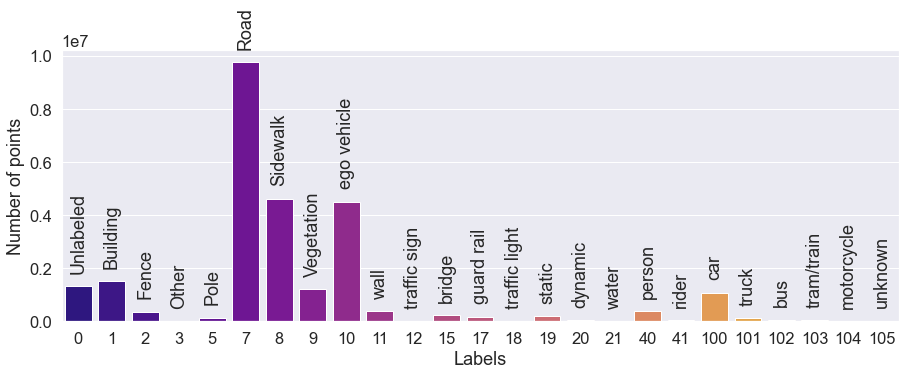

```python
import matplotlib.pyplot as plt
import seaborn as sns
sns.set_theme(style="darkgrid", font_scale=1.5, palette="Dark2")

fig, ax = plt.subplots(figsize=(15, 5))
sns.barplot(x='labels', y='counts', data=labels_df, ax=ax, palette="plasma")
ax.set_xlabel('Labels')
ax.set_ylabel('Number of points')

xticks = ax.get_xticklabels()
# add name as vertical text to the bars
for xx in xticks:
    xindex = int(xx.get_text())
    xvalue = xx.get_position()[0]
    label_name = label_name_map [xindex]
    try:
        label_count = labels_df[labels_df['labels'] == xindex]['counts'].to_numpy()[0] + 0.05e7
    except:
        label_count = 0

    ax.text(xvalue, label_count, label_name, rotation=90, va='bottom', ha='center', fontsize=18)
```

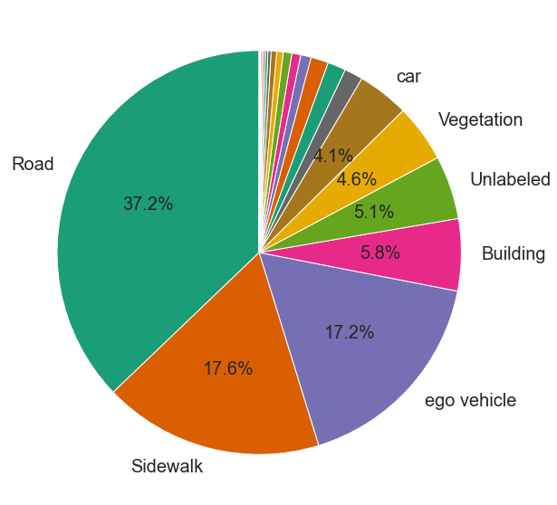

```python
# pie chart
fig, ax = plt.subplots(figsize=(10, 10))
ax.axis('equal')  # Equal aspect ratio ensures that pie is drawn as a circle.
# dont show the labels for the small slices in percentage
autopct=lambda pct: '{:1.1f}%'.format(pct) if pct > 3 else ''
wedges, texts, autotexts =  ax.pie(labels_df['percentage'], labels=labels_df['labels_names'],
                    autopct=autopct, startangle=90, textprops={'fontsize': 20})
# dont show the labels for the small slices in percentage
for at, t in zip(autotexts, texts):
    if at.get_text() == '':
        t.set_text('')
```

### Point cloud visualization

Before going through the compression methods, let us visualize the point clouds, in order to have a high level idea of the dataset we are considering.

[figure not shown]

```python
import numpy as np
import matplotlib.pyplot as plt
import os
import glob
from pyntcloud import PyntCloud
import plyfile as ply
import sys
import DracoPy
import shutil
import pandas as pd
```

# Draco Compression

The Draco codec is a compression library for 3D geometric meshes and point clouds. It uses a combination of techniques, including entropy encoding and mesh simplification, to significantly reduce the file size of 3D models while still maintaining a high degree of visual quality. The compression process involves analyzing the geometry of the mesh to identify and remove redundant or unnecessary data, and then using advanced encoding techniques to represent the remaining data as efficiently as possible.

[figure not shown]

## Preprocessing of the data to build the merged Dataset

```python
import open3d as o3d
from tqdm import tqdm

def combine (
    main_dir,
    Nfiles=100,
    outdir='dataset_final',
    ):
    import glob
    # find all scan codes
    left_lidar_codes = glob.glob(os.path.join(main_dir, 'LIDAR_FRONT_LEFT', '*.ply'))
    left_lidar_codes = [f.split('/')[-1].split('.')[0] for f in left_lidar_codes]
    left_lidar_codes.sort()
    print (f"Number of left lidar codes: {len(left_lidar_codes)}")

    right_lidar_codes = glob.glob(os.path.join(main_dir, 'LIDAR_FRONT_RIGHT', '*.ply'))
    right_lidar_codes = [f.split('/')[-1].split('.')[0] for f in right_lidar_codes]
    right_lidar_codes.sort()
    print (f"Number of left lidar codes: {len(left_lidar_codes)}")

    top_lidar_codes = glob.glob(os.path.join(main_dir, 'LIDAR_TOP', '*.ply'))
    top_lidar_codes = [f.split('/')[-1].split('.')[0] for f in top_lidar_codes]
    top_lidar_codes.sort()
    print (f"Number of left lidar codes: {len(left_lidar_codes)}")

    # find intersection of scan code
    print ("Finding intersection of scan codes")
    scan_codes = set(left_lidar_codes).intersection(set(right_lidar_codes)).intersection(set(top_lidar_codes))
    scan_codes = list(scan_codes)
    scan_codes.sort()
    scan_codes = scan_codes[:Nfiles]
    print (f"Number of scan codes: {len(scan_codes)}")


    # combine lidar data
    all_lidars = ['LIDAR_FRONT_LEFT', 'LIDAR_FRONT_RIGHT', 'LIDAR_TOP']
    outdir = os.path.join(main_dir, outdir)
    if not os.path.exists(outdir):
        os.makedirs(outdir)

    # save combined point clouds and labels
    for code in tqdm(scan_codes):
        pcd_combined = o3d.geometry.PointCloud()
        labels = []
        for lidar in all_lidars:
            file = os.path.join(main_dir, lidar,  code + '.ply')
            # load labels, i.e the  PlyProperty('ObjTag', 'uchar')), fourth property of the ply file
            plydata = ply.PlyData.read(file)
            labels += list(np.array(plydata.elements[0].data['ObjTag']))

            # load point clouds
            pc = o3d.io.read_point_cloud(file, format='ply')
            pcd_combined += pc



        # get labels
        labels = np.array(labels)
        #save labels
        # np.save(os.path.join(outdir, code + '_labels.npy'), labels)
        o3d.io.write_point_cloud(os.path.join(outdir, code + '.ply'), pcd_combined)

        # read again the file with plyfile and add the labels as a property
        plydata = ply.PlyData.read(os.path.join(outdir, code + '.ply'))

        # add the labels as a property
        x, y, z = plydata.elements[0].data['x'], plydata.elements[0].data['y'], plydata.elements[0].data['z']
        element = ply.PlyElement.describe(np.array(list(zip(x, y, z, labels)), dtype=[('x', 'f4'), ('y', 'f4'), ('z', 'f4'), ('ObjTag', 'u1')]), 'vertex')
        plydata.elements = [element]
        plydata.write(os.path.join(outdir, code + '.ply'))
```

```python
#  create the final dataset

main_dir = 'dataset-downloader-kit/CV/dataset/Town01_Opt_ClearSunset'
combine(main_dir, Nfiles=100, outdir='dataset_final')
```

Draco compression over the whole merged directory

```python
import time
import plyfile

path_to_combined_data = 'dataset-downloader-kit/CV/dataset/Town01_Opt_ClearSunset/dataset_final'
all_pc = glob.glob(os.path.join(path_to_combined_data, '*.ply'))
```

## Quality metric

It is possible to define different quality metrics to evaluate the quality of the compression in a pointcloud scenario.

In this case we decide to apply, mostly for computational reasons, the mean point distance error.

```python
from scipy.spatial import KDTree
def mean_point_distance_error(points, decoded_points):

    # Create a KDTree of the decoded points
    decoded_points_tree = KDTree(decoded_points)
    # Find the closest point in the decoded point cloud for each point in the original point cloud
    distances, closest_indices = decoded_points_tree.query(points)
    # Get the closest points
    closest_points = decoded_points[closest_indices]
    # Calculate the mean point distance error
    mpde = np.mean(np.linalg.norm(points - closest_points, axis=1))
    return mpde
```

## Unlabelled pointcloud compression

- Compression ratio
- Mean point distance error
- Number of lost points
- Computation time

Note that compression ratio is computed as the ratio between the size of the compressed file and the size of the original file:

$$ \frac{size_{compressed}}{size_{original}} $$

Therefore, it represents how much the file has been compressed. The lower the better.

```python
draco_unlabeled = pd.DataFrame(columns=['filename', 'original_size', 'original_size_bytes',
                                        'encoded_size',
                                        'compression_ratio',
                                        'encoding_decoding_time', 'lost_points', 'mpde'])

for pc in all_pc:

    # Start the timer
    start = time.time()

    # Read the ply file
    plydata = plyfile.PlyData.read(pc)
    # Extract the XYZ coordinates of the points
    points = np.vstack([plydata['vertex']['x'], plydata['vertex']['y'], plydata['vertex']['z']]).T

    # Measure the number of points in the original point cloud
    original_size = len(points)
    original_size_bytes = len(points.tobytes())


    # Encode the point cloud
    encoded_data = DracoPy.encode(points)
    encoded_size_bytes = len(encoded_data)

    # Measure the size of the encoded data
    encoded_size = len(encoded_data)
     # Calculate the compression ratio
    encoded_compression_ratio = (encoded_size_bytes / original_size_bytes)

    print (f"Original size: {original_size_bytes} points\tEncoded size: {encoded_size_bytes} bytes, \t Compression ratio: {encoded_compression_ratio}")

    # Decode the encoded data
    decoded_points = DracoPy.decode(encoded_data)
    # End the timer
    end = time.time()

    # save the decoded points
    decoded_points_filename = os.path.join('results', 'draco_unlabeled_decoded')

    # save the decoded points
    if not os.path.exists(decoded_points_filename):
        os.makedirs(decoded_points_filename)

    decoded_points_filename = os.path.join(decoded_points_filename, os.path.basename(pc))
    ply_decoded = plyfile.PlyData(\
        [plyfile.PlyElement.describe(\
            np.array(list(zip(decoded_points.points[:,0],
            decoded_points.points[:,1],
            decoded_points.points[:,2])),
            dtype=[('x', 'f4'), ('y', 'f4'), ('z', 'f4')]), 'vertex')])

    ply_decoded.write(decoded_points_filename + '.ply')

    #metric for quality of the decoded points
    mpde = mean_point_distance_error(points, decoded_points.points)

    # fiond nearest points to the decoded points in the original point cloud
    lost_points = len(points) - len(decoded_points.points)

    # Save the results
    draco_unlabeled = draco_unlabeled.append({'filename': pc,
                                            'original_size': original_size,
                                            'original_size_bytes': original_size_bytes,
                                            'encoded_size': encoded_size,
                                            'compression_ratio': encoded_compression_ratio,
                                            'encoding_decoding_time': end - start,
                                            'lost_points': lost_points,
                                            'mpde': mpde
                                            },
                                            ignore_index=True)

# save the results
draco_unlabeled.to_csv('results/draco_unlabeled.csv', index=False)
```

```python
draco_unlabeled = pd.read_csv('results/draco_unlabeled.csv')

try:
    draco_unlabeled = draco_unlabeled.drop(columns=['encoded_size_bytes', 'compression_ratio_bytes'])
except:
    pass

draco_unlabeled
```

|  | filename | original_size | original_size_bytes | encoded_size | compression_ratio | encoding_decoding_time | lost_points | mpde |
| --- | --- | --- | --- | --- | --- | --- | --- | --- |
| 0 | dataset-downloader-kit/CV/dataset/Town01_Opt_C... | 284674 | 3416088 | 314512 | 0.092068 | 0.615055 | 0 | 0.005322 |
| 1 | dataset-downloader-kit/CV/dataset/Town01_Opt_C... | 270973 | 3251676 | 299772 | 0.092190 | 0.452345 | 0 | 0.005561 |
| 2 | dataset-downloader-kit/CV/dataset/Town01_Opt_C... | 288527 | 3462324 | 334056 | 0.096483 | 0.349651 | 1316 | 0.006069 |
| 3 | dataset-downloader-kit/CV/dataset/Town01_Opt_C... | 272889 | 3274668 | 296048 | 0.090406 | 0.356713 | 3754 | 0.005172 |
| 4 | dataset-downloader-kit/CV/dataset/Town01_Opt_C... | 273193 | 3278316 | 286544 | 0.087406 | 0.392556 | 565 | 0.005175 |
| ... | ... | ... | ... | ... | ... | ... | ... | ... |
| 91 | dataset-downloader-kit/CV/dataset/Town01_Opt_C... | 290365 | 3484380 | 337264 | 0.096793 | 0.458859 | 3561 | 0.005114 |
| 92 | dataset-downloader-kit/CV/dataset/Town01_Opt_C... | 283939 | 3407268 | 319548 | 0.093784 | 0.544925 | 433 | 0.004996 |
| 93 | dataset-downloader-kit/CV/dataset/Town01_Opt_C... | 268975 | 3227700 | 309704 | 0.095952 | 0.411857 | 603 | 0.005946 |
| 94 | dataset-downloader-kit/CV/dataset/Town01_Opt_C... | 271360 | 3256320 | 298220 | 0.091582 | 0.419531 | 306 | 0.005488 |
| 95 | dataset-downloader-kit/CV/dataset/Town01_Opt_C... | 274077 | 3288924 | 283980 | 0.086344 | 0.502103 | 467 | 0.005999 |

96 rows × 8 columns

```python
# plot some results
import matplotlib.pyplot as plt
import seaborn as sns
sns.set_theme(style='whitegrid', font_scale=1.5)


# aggregate the results
stats = pd.DataFrame(columns=draco_unlabeled.columns)
stats.loc['avg'] = draco_unlabeled.mean()
stats.loc['std'] = draco_unlabeled.std()

print (f" Average compression ratio: {stats.loc['avg', 'compression_ratio'] * 100:.1f} % pm {stats.loc['std', 'compression_ratio'] * 100:.1f} %")
print (f" Average encoding-decoding time: {stats.loc['avg', 'encoding_decoding_time']:.2f} seconds pm {stats.loc['std', 'encoding_decoding_time']:.2f} seconds")
print (f" Average lost points: {stats.loc['avg', 'lost_points']:.2f} points pm {stats.loc['std', 'lost_points']:.2f} points")
print (f" Average MPDE: {stats.loc['avg', 'mpde']:4f} meters pm {stats.loc['std', 'mpde']:.4f} meters")
```

```
 Average compression ratio: 8.9 % pm 0.5 %
 Average encoding-decoding time: 0.42 seconds pm 0.07 seconds
 Average lost points: 1861.33 points pm 1578.30 points
 Average MPDE: 0.005557 meters pm 0.0005 meters
```

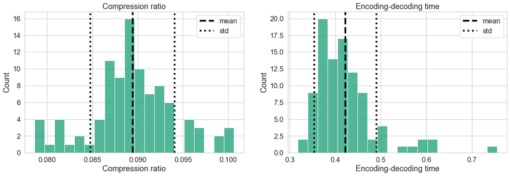

```python
# plot
sns.set_theme(style='whitegrid', font_scale=1.5, palette='Dark2')
fig, ax = plt.subplots(1, 2, figsize=(20, 6))
sns.histplot(data=draco_unlabeled, x='compression_ratio', ax=ax[0], bins=20)
sns.histplot(data=draco_unlabeled, x='encoding_decoding_time', ax=ax[1], bins=20)

# add mean and std
lw = 4
ax[0].set_title('Compression ratio')
ax[1].set_title('Encoding-decoding time')

ax[0].set_xlabel('Compression ratio')
ax[1].set_xlabel('Encoding-decoding time')


ax[0].axvline(stats.loc['avg', 'compression_ratio'], color='black', linestyle='--', label='mean', linewidth=lw)
ax[0].axvline(stats.loc['avg', 'compression_ratio'] + stats.loc['std', 'compression_ratio'], color='black', linestyle=':', label='std', linewidth=lw)
ax[0].axvline(stats.loc['avg', 'compression_ratio'] - stats.loc['std', 'compression_ratio'], color='black', linestyle=':', linewidth=lw)
ax[0].legend()

ax[1].axvline(stats.loc['avg', 'encoding_decoding_time'], color='black', linestyle='--', label='mean', linewidth=lw)
ax[1].axvline(stats.loc['avg', 'encoding_decoding_time'] + stats.loc['std', 'encoding_decoding_time'], color='black', linestyle=':', label='std', linewidth=lw)
ax[1].axvline(stats.loc['avg', 'encoding_decoding_time'] - stats.loc['std', 'encoding_decoding_time'], color='black', linestyle=':', linewidth=lw)
ax[1].legend()
```

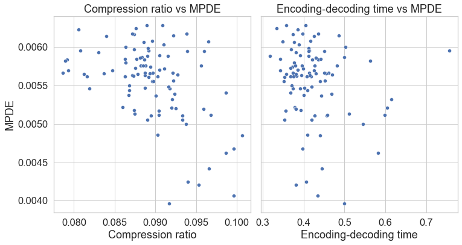

```python
# quality vs compression
sns.set_theme(style='whitegrid', font_scale=1.5, palette='deep')

fig, ax = plt.subplots(1, 2, figsize=(12, 6))
sns.scatterplot(data=draco_unlabeled, x='compression_ratio', y='mpde', ax=ax[0])
sns.scatterplot(data=draco_unlabeled, x='encoding_decoding_time', y='mpde', ax=ax[1])
ax[0].set_title('Compression ratio vs MPDE')
ax[1].set_title('Encoding-decoding time vs MPDE')
ax[0].set_xlabel('Compression ratio')
ax[1].set_xlabel('Encoding-decoding time')
ax[0].set_ylabel('MPDE')
ax[1].set_ylabel('')
ax[1].set_yticklabels([])
# ax[0].set_xticks(np.arange(0.
# share axis
ax[0].set_ylim(ax[1].get_ylim())
fig.subplots_adjust(wspace=0.05)
```

## Labeled pointcloud

Let us now consider the dataset with the corresponding labels. In this case we compress the point cloud obtained by compressing each label individually and we compute all the considered metrics.

```python
def draco_labeled (pc_file):
    # Read the ply file
    plydata = plyfile.PlyData.read(pc_file)

    # Extract the XYZ coordinates of the points
    points = np.column_stack((plydata['vertex']['x'], plydata['vertex']['y'], plydata['vertex']['z']))
    # Extract the labels of the points
    labels = plydata['vertex']['ObjTag']
    print (f"Number of labels: {len(np.unique(labels))}")

    # iterate over the labels and encode each label separately

    results_PC = pd.DataFrame(columns=['label',
                                        'original_size',
                                        'encoded_size',
                                        'compression_ratio',
                                        'encoding_decoding_time',
                                        'lost_points', 'mpde'])

    for label in np.unique(labels):
        start = time.time()
        mask = labels == label

        pc_label = points[mask]
        # print (f"Number of points in label {label}: {len(pc_label)}")

        # Encode the point cloud
        encoded_data = DracoPy.encode(pc_label)

        # Measure the size of the encoded data
        encoded_size = len(encoded_data)
        encoded_size_bytes = len(encoded_data)
        original_size_bytes = sys.getsizeof(pc_label.tobytes())

        # Measure the number of points in the original point cloud
        original_size = len(points)
        print (f"Original size: {original_size_bytes} bytes \t Encoded size: {encoded_size_bytes} bytes")
        # Decode the encoded data
        decoded_points = DracoPy.decode(encoded_data)

        mpde = mean_point_distance_error(pc_label, decoded_points.points)

        # End the timer
        end = time.time()

        # Calculate the compression ratio
        compression_ratio_bytes =  (encoded_size_bytes / original_size_bytes)

        # Calculate the number of lost points
        lost_points = len(points) - len(decoded_points.points)
        results_PC = results_PC.append({'label': label,
                                        'original_size': original_size,
                                        'encoded_size': encoded_size,
                                        'compression_ratio': compression_ratio_bytes,
                                        'encoding_decoding_time': end - start,
                                        'lost_points': lost_points,
                                        'mpde': mpde
                                        },
                                        ignore_index=True)

    # save the results
    img_name = pc_file.split('/')[-1].split('.')[0]
    res_dir = 'results'

    results_PC.to_csv(os.path.join(res_dir, img_name+'draco_labeled.csv'), index=False)

    return results_PC
```

```python
# go through all the files and save the results
draco_labeled_res = dict()
for file in all_pc:
    draco_labeled_res[file] = draco_labeled(file)
```

```
Number of labels: 18
Original size: 537 bytes 	 Encoded size: 256 bytes
Original size: 535365 bytes 	 Encoded size: 91892 bytes
Original size: 7221 bytes 	 Encoded size: 1780 bytes
Original size: 11049 bytes 	 Encoded size: 1988 bytes
Original size: 1082925 bytes 	 Encoded size: 102120 bytes
Original size: 699273 bytes 	 Encoded size: 95308 bytes
Original size: 4353 bytes 	 Encoded size: 1268 bytes
Original size: 562653 bytes 	 Encoded size: 70192 bytes
Original size: 138417 bytes 	 Encoded size: 25412 bytes
Original size: 81 bytes 	 Encoded size: 96 bytes
Original size: 1149 bytes 	 Encoded size: 356 bytes
Original size: 321 bytes 	 Encoded size: 152 bytes
Original size: 83997 bytes 	 Encoded size: 12940 bytes
Original size: 46125 bytes 	 Encoded size: 7016 bytes
Original size: 31857 bytes 	 Encoded size: 5144 bytes
Original size: 196389 bytes 	 Encoded size: 16640 bytes
Original size: 13821 bytes 	 Encoded size: 3768 bytes
Original size: 1149 bytes 	 Encoded size: 400 bytes
Number of labels: 20
Original size: 64101 bytes 	 Encoded size: 14424 bytes
Original size: 202629 bytes 	 Encoded size: 39520 bytes
Original size: 21741 bytes 	 Encoded size: 4716 bytes
Original size: 369 bytes 	 Encoded size: 200 bytes
Original size: 16149 bytes 	 Encoded size: 3148 bytes
Original size: 1186353 bytes 	 Encoded size: 102576 bytes
Original size: 721269 bytes 	 Encoded size: 89860 bytes
Original size: 175485 bytes 	 Encoded size: 37444 bytes
Original size: 562653 bytes 	 Encoded size: 70176 bytes
Original size: 11709 bytes 	 Encoded size: 2416 bytes
Original size: 33333 bytes 	 Encoded size: 6696 bytes
Original size: 2889 bytes 	 Encoded size: 660 bytes
Original size: 67581 bytes 	 Encoded size: 8744 bytes
Original size: 729 bytes 	 Encoded size: 244 bytes
Original size: 117717 bytes 	 Encoded size: 17020 bytes
Original size: 7185 bytes 	 Encoded size: 1320 bytes
Original size: 52269 bytes 	 Encoded size: 8464 bytes
Original size: 585 bytes 	 Encoded size: 288 bytes
Original size: 3393 bytes 	 Encoded size: 1080 bytes
Original size: 4197 bytes 	 Encoded size: 884 bytes
```

[output cut: 1838 more lines]

```
Original size: 12801 bytes 	 Encoded size: 2440 bytes
Original size: 1196841 bytes 	 Encoded size: 102624 bytes
Original size: 620433 bytes 	 Encoded size: 72440 bytes
Original size: 151245 bytes 	 Encoded size: 30364 bytes
Original size: 562653 bytes 	 Encoded size: 70184 bytes
Original size: 267885 bytes 	 Encoded size: 38644 bytes
Original size: 3213 bytes 	 Encoded size: 836 bytes
Original size: 213 bytes 	 Encoded size: 144 bytes
Original size: 333 bytes 	 Encoded size: 180 bytes
Original size: 118485 bytes 	 Encoded size: 16688 bytes
Original size: 3825 bytes 	 Encoded size: 1356 bytes
Original size: 77877 bytes 	 Encoded size: 10472 bytes
Original size: 45 bytes 	 Encoded size: 80 bytes
Original size: 6381 bytes 	 Encoded size: 1432 bytes
Original size: 25449 bytes 	 Encoded size: 5284 bytes
```

```python
# read files
draco_labeled_res = dict()
for file in all_pc:
    img_name = file.split('/')[-1].split('.')[0]
    res_dir = 'results'
    draco_labeled_res[file] = pd.read_csv(os.path.join(res_dir, img_name+'draco_labeled.csv'))
```

```python
draco_labeled_res[file]
```

|  | label | original_size | encoded_size | encoding_decoding_time | lost_points | mpde | compression_ratio |
| --- | --- | --- | --- | --- | --- | --- | --- |
| 0 | 0.0 | 274077.0 | 1144.0 | 0.003294 | 273738.0 | 0.003797 | 0.278956 |
| 1 | 1.0 | 274077.0 | 38856.0 | 0.049923 | 257984.0 | 0.003774 | 0.201159 |
| 2 | 2.0 | 274077.0 | 8352.0 | 0.010851 | 270365.0 | 0.005662 | 0.187361 |
| 3 | 5.0 | 274077.0 | 2440.0 | 0.004791 | 273013.0 | 0.005171 | 0.190610 |
| 4 | 7.0 | 274077.0 | 102624.0 | 0.312609 | 174783.0 | 0.003533 | 0.085746 |
| 5 | 8.0 | 274077.0 | 72440.0 | 0.162096 | 222403.0 | 0.004278 | 0.116757 |
| 6 | 9.0 | 274077.0 | 30364.0 | 0.051827 | 261476.0 | 0.005247 | 0.200760 |
| 7 | 10.0 | 274077.0 | 70184.0 | 0.131092 | 227192.0 | 0.000159 | 0.124738 |
| 8 | 11.0 | 274077.0 | 38644.0 | 0.058764 | 251756.0 | 0.002873 | 0.144256 |
| 9 | 12.0 | 274077.0 | 836.0 | 0.003122 | 273812.0 | 0.000685 | 0.260193 |
| 10 | 17.0 | 274077.0 | 144.0 | 0.001490 | 274062.0 | 0.000172 | 0.676056 |
| 11 | 18.0 | 274077.0 | 180.0 | 0.001290 | 274052.0 | 0.000693 | 0.540541 |
| 12 | 19.0 | 274077.0 | 16688.0 | 0.027093 | 264206.0 | 0.003831 | 0.140845 |
| 13 | 20.0 | 274077.0 | 1356.0 | 0.002389 | 273761.0 | 0.000099 | 0.354510 |
| 14 | 40.0 | 274077.0 | 10472.0 | 0.018137 | 267590.0 | 0.005384 | 0.134468 |
| 15 | 41.0 | 274077.0 | 80.0 | 0.002053 | 274076.0 | 0.000000 | 1.777778 |
| 16 | 100.0 | 274077.0 | 1432.0 | 0.002978 | 273548.0 | 0.004162 | 0.224416 |
| 17 | 105.0 | 274077.0 | 5284.0 | 0.009932 | 271959.0 | 0.000775 | 0.207631 |

```python
# stats for each label
stats_labels = pd.DataFrame(columns=['label',
                                    'avg_compression_ratio',
                                    'std_compression_ratio',
                                    'avg_encoding_decoding_time',
                                    'std_encoding_decoding_time',
                                    'avg_lost_points/total_points',
                                    'std_lost_points/total_points',
                                    'avg_mpde',
                                    ])
# for each label plot the avg compression ratio and the avg encoding-decoding time

all_labels = np.unique(np.concatenate([draco_labeled_res[file]['label'].values for file in all_pc]))
for label in all_labels:
    avg_compression_ratio = np.mean([draco_labeled_res[file][draco_labeled_res[file]['label'] == label]['compression_ratio'].iloc[0] for file in all_pc if label in draco_labeled_res[file]['label'].values])
    std_compression_ratio = np.std([draco_labeled_res[file][draco_labeled_res[file]['label'] == label]['compression_ratio'].iloc[0] for file in all_pc if label in draco_labeled_res[file]['label'].values])
    avg_encoding_decoding_time = np.mean([draco_labeled_res[file][draco_labeled_res[file]['label'] == label]['encoding_decoding_time'].iloc[0] for file in all_pc if label in draco_labeled_res[file]['label'].values])
    std_encoding_decoding_time = np.std([draco_labeled_res[file][draco_labeled_res[file]['label'] == label]['encoding_decoding_time'].iloc[0] for file in all_pc if label in draco_labeled_res[file]['label'].values])
    avg_lost_points = np.mean([draco_labeled_res[file][draco_labeled_res[file]['label'] == label]['lost_points']/draco_labeled_res[file][draco_labeled_res[file]['label'] == label]['original_size'].iloc[0]  for file in all_pc if label in draco_labeled_res[file]['label'].values])
    std_lost_points = np.std([draco_labeled_res[file][draco_labeled_res[file]['label'] == label]['lost_points']/draco_labeled_res[file][draco_labeled_res[file]['label'] == label]['original_size'].iloc[0]  for file in all_pc if label in draco_labeled_res[file]['label'].values])
    avg_mpde = np.mean([draco_labeled_res[file][draco_labeled_res[file]['label'] == label]['mpde'].iloc[0] for file in all_pc if label in draco_labeled_res[file]['label'].values])

    stats_labels = stats_labels.append({'label': label,
                                        'avg_compression_ratio': avg_compression_ratio,
                                        'std_compression_ratio': std_compression_ratio,
                                        'avg_encoding_decoding_time': avg_encoding_decoding_time,
                                        'std_encoding_decoding_time': std_encoding_decoding_time,
                                        'avg_lost_points/total_points': avg_lost_points,
                                        'std_lost_points/total_points': std_lost_points,
                                        'avg_mpde': avg_mpde
                                        },
                                        ignore_index=True)
```

```python
stats_labels
```

|  | label | avg_compression_ratio | std_compression_ratio | avg_encoding_decoding_time | std_encoding_decoding_time | avg_lost_points/total_points | std_lost_points/total_points | avg_mpde |
| --- | --- | --- | --- | --- | --- | --- | --- | --- |
| 0 | 0.0 | 0.213979 | 0.065690 | 0.046912 | 0.051920 | 0.949713 | 0.057275 | 0.004285 |
| 1 | 1.0 | 0.207564 | 0.045764 | 0.055434 | 0.041921 | 0.939731 | 0.043845 | 0.004182 |
| 2 | 2.0 | 0.215043 | 0.100345 | 0.013153 | 0.013533 | 0.985899 | 0.017724 | 0.004154 |
| 3 | 3.0 | 0.724464 | 0.390792 | 0.001846 | 0.000510 | 0.999755 | 0.000449 | 0.000327 |
| 4 | 5.0 | 0.178832 | 0.037474 | 0.005670 | 0.002732 | 0.994832 | 0.002975 | 0.004658 |
| 5 | 7.0 | 0.090361 | 0.006316 | 0.329025 | 0.057278 | 0.634253 | 0.044794 | 0.003427 |
| 6 | 8.0 | 0.124917 | 0.010122 | 0.155289 | 0.038902 | 0.823944 | 0.038224 | 0.003688 |
| 7 | 9.0 | 0.217767 | 0.117306 | 0.038156 | 0.019669 | 0.954100 | 0.024590 | 0.004989 |
| 8 | 10.0 | 0.124748 | 0.000021 | 0.141588 | 0.016786 | 0.828065 | 0.006561 | 0.000159 |
| 9 | 11.0 | 0.227799 | 0.082529 | 0.015390 | 0.015277 | 0.984710 | 0.018950 | 0.003460 |
| 10 | 12.0 | 0.735115 | 0.503065 | 0.002184 | 0.001161 | 0.999641 | 0.000543 | 0.000728 |
| 11 | 15.0 | 0.415259 | 0.458475 | 0.014904 | 0.021064 | 0.982442 | 0.027719 | 0.002237 |
| 12 | 17.0 | 0.382645 | 0.295025 | 0.010771 | 0.018186 | 0.987601 | 0.023943 | 0.001388 |
| 13 | 18.0 | 0.524343 | 0.458984 | 0.001968 | 0.000457 | 0.999546 | 0.000348 | 0.002141 |
| 14 | 19.0 | 0.255264 | 0.195003 | 0.007335 | 0.009060 | 0.992477 | 0.009527 | 0.003158 |
| 15 | 20.0 | 0.376955 | 0.267165 | 0.003016 | 0.002817 | 0.998152 | 0.003431 | 0.002558 |
| 16 | 21.0 | 0.373665 | 0.070440 | 0.002410 | 0.001299 | 0.999038 | 0.001303 | 0.001491 |
| 17 | 40.0 | 0.161903 | 0.036578 | 0.012460 | 0.006683 | 0.985153 | 0.008057 | 0.004768 |
| 18 | 41.0 | 0.412539 | 0.370558 | 0.002608 | 0.001437 | 0.998672 | 0.001930 | 0.002464 |
| 19 | 100.0 | 0.144662 | 0.036092 | 0.032281 | 0.026846 | 0.958732 | 0.032902 | 0.004330 |
| 20 | 101.0 | 0.322917 | 0.118224 | 0.013310 | 0.025806 | 0.985622 | 0.031362 | 0.001090 |
| 21 | 102.0 | 0.358440 | 0.169791 | 0.025390 | 0.053780 | 0.973558 | 0.054686 | 0.000665 |
| 22 | 103.0 | 0.371783 | 0.269854 | 0.005591 | 0.010099 | 0.995131 | 0.013423 | 0.001417 |
| 23 | 104.0 | 0.762646 | 0.513707 | 0.002033 | 0.000799 | 0.999617 | 0.000832 | 0.000828 |
| 24 | 105.0 | 0.430213 | 0.321163 | 0.002429 | 0.001296 | 0.998880 | 0.001576 | 0.002148 |

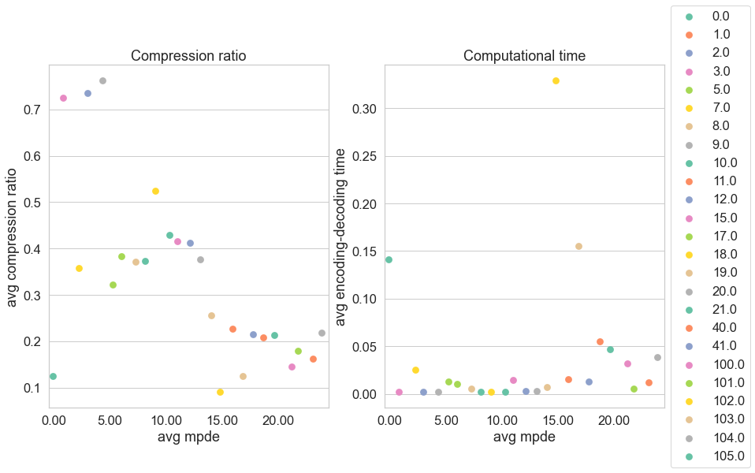

```python
# plot the results
import seaborn as sns
fig, ax = plt.subplots(1, 2, figsize=(14, 8))

sns.set_theme(style="whitegrid", font_scale=1.5)
# add error bars
# ax[0].errorbar(stats_labels['avg_lost_points/total_points'], y=stats_labels['avg_compression_ratio'], yerr=stats_labels['std_compression_ratio'], fmt='o', color='black')
sns.pointplot(x='avg_mpde', y='avg_compression_ratio', data=stats_labels,
                ax=ax[0], dodge=True, join=False, palette='Set2', hue='label')


ax[0].set_xlabel('avg mpde')
ax[0].set_ylabel('avg compression ratio')
ax[0].set_title('Compression ratio')
# set xticks with double precision
from matplotlib.ticker import FormatStrFormatter
ax[0].xaxis.set_major_formatter(FormatStrFormatter('%.2f'))

# print xticks every 5 ticks
for i, label in enumerate(ax[0].get_xticklabels()):
    if i % 5 != 0:
        label.set_visible(False)


#remove the legend
ax[0].legend_.remove()

sns.pointplot(x='avg_mpde', y='avg_encoding_decoding_time', data=stats_labels,  ax=ax[1], dodge=True, join=False, palette='Set2', hue='label')
ax[1].set_xlabel('avg mpde')
ax[1].set_ylabel('avg encoding-decoding time')
ax[1].set_title('Computational time')
# put legend outside the plot
ax[1].legend(loc='center left', bbox_to_anchor=(1, 0.5), ncol=1)

# set xticks with double precision
from matplotlib.ticker import FormatStrFormatter
ax[1].xaxis.set_major_formatter(FormatStrFormatter('%.2f'))

# print xticks every 5 ticks
for i, label in enumerate(ax[1].get_xticklabels()):
    if i % 5 != 0:
        label.set_visible(False)

plt.show()
```

# DBscan based compression

DBSCAN (Density-Based Spatial Clustering of Applications with Noise) is a density-based clustering algorithm that groups together data points that are closely packed together (i.e., dense regions) and separates data points that are far apart (i.e., sparse regions).

The algorithm works by defining a neighborhood around each data point, and then grouping together all data points that have a sufficient number of nearby data points within their defined neighborhood. Two parameters, Eps and MinPts, are required for DBSCAN to work. Eps is the maximum distance between two points for them to be considered as a density-connected points and MinPts is the minimum number of points required to form a dense region.

A point is considered a core point if there are at least MinPts points within a distance of Eps from it. A point is considered a border point if there are fewer than MinPts within a distance of Eps, but it is in the neighborhood of a core point. A point is considered an outlier point if it is neither a core point nor a border point.

```python
import numpy as np
import matplotlib.pyplot as plt
import os
import glob
from sklearn.cluster import DBSCAN
import time
```

```python
!pip install pyntcloud
from pyntcloud import PyntCloud
```

```python
!pip install pyntcloud plyfile
import plyfile
```

```python
from google.colab import drive
drive.mount('/content/drive')

directory='/content/drive/MyDrive/3DAR/dataset_final/dataset_final'
```

## Metrics and tuning strategy

We employed a parameter search optimization; enabling a comparison of eps_values and min_samples_values to be tuned for each class in each point cloud.

Moreover, in this instance, the quality of the assessments that we decided to implement to compare the different configurations is based on the following distance:

The **Chamfer distance** first introduced in computer vision by Borgefors in 1986 in his paper "Distance transformations in digital images", is a technique used in computer vision and image processing to measure the similarity between two shapes. It calculates the distance between two sets of points, typically two point clouds or two images. The distance between two points is defined as the minimum Euclidean distance between any point in one set and any point in the other set. The Chamfer distance is the sum of these distances over all points in one set, typically normalized by the number of points in the set.

It's known as a robust method to compare shapes since it doesn't require a one-to-one correspondence between the points of the two sets and it's also less sensitive to noise, occlusion and point density changes.

```python
import numpy as np
from sklearn.cluster import DBSCAN

# List of eps values to test
eps_values = [0.05,0.075,0.1]
# List of min_samples values to test
min_samples_values = [5, 10, 15, 20]

counter = 0
for file in os.scandir(directory):
    if file.name.endswith('.ply') and file.is_file():
        plydata = plyfile.PlyData.read(file.path)
        points = np.column_stack((plydata['vertex']['x'], plydata['vertex']['y'], plydata['vertex']['z']))
        labels = plydata['vertex']['ObjTag']
        # Iterate over the classes
        for label in np.unique(labels):
            class_points = points[labels == label]
            best_params = {'eps': None, 'min_samples': None, 'score': float('inf')}
            for eps in eps_values:
                for min_samples in min_samples_values:
                    # Apply DBSCAN with the current parameters
                    dbscan = DBSCAN(eps=eps, min_samples=min_samples)
                    dbscan.fit(class_points)
                    cluster_labels = dbscan.labels_
                    # Get the representative points for each cluster
                    compressed_cloud = np.array([class_points[cluster_labels == i].mean(axis=0) for i in np.unique(cluster_labels) if i != -1])
                    compressed_points_count = len(compressed_cloud)
                    if compressed_points_count > 0:
                        chamfer_distance = np.mean(np.min(np.linalg.norm(class_points[:, np.newaxis] - compressed_cloud, axis=2), axis=1))
                        # Compare the chamfer distance with the best score found so far
                        if chamfer_distance < best_params['score']:
                            best_params['eps'] = eps
                            best_params['min_samples'] = min_samples
                            best_params['score'] = chamfer_distance
                            best_params['compressed_cloud'] = compressed_cloud
            if 'compressed_cloud' in best_params and best_params['compressed_cloud'] is not None:
                print("Best parameters found for class {} in point cloud {}: eps={}, min_samples={}; score={}".format(label, counter, best_params['eps'], best_params['min_samples'], best_params['score']))
            else:
                print(f"No points in compressed cloud for class {label}")
        counter +=1
```

```
Best parameters found for class 1 in point cloud 0: eps=0.1, min_samples=5; score=12.026824951171875
Best parameters found for class 2 in point cloud 0: eps=0.1, min_samples=5; score=16.696317672729492
Best parameters found for class 5 in point cloud 0: eps=0.1, min_samples=5; score=12.717296600341797
Best parameters found for class 7 in point cloud 0: eps=0.1, min_samples=5; score=1.1805081367492676
Best parameters found for class 8 in point cloud 0: eps=0.1, min_samples=5; score=1.181670069694519
No points in compressed cloud for class 9
Best parameters found for class 10 in point cloud 0: eps=0.05, min_samples=5; score=0.12841619551181793
No points in compressed cloud for class 11
No points in compressed cloud for class 12
Best parameters found for class 17 in point cloud 0: eps=0.1, min_samples=5; score=1.1816720962524414
Best parameters found for class 18 in point cloud 0: eps=0.1, min_samples=5; score=9.287215232849121
Best parameters found for class 19 in point cloud 0: eps=0.1, min_samples=5; score=8.806918144226074
No points in compressed cloud for class 20
Best parameters found for class 40 in point cloud 0: eps=0.1, min_samples=5; score=6.662369251251221
Best parameters found for class 41 in point cloud 0: eps=0.1, min_samples=5; score=0.9406567215919495
Best parameters found for class 100 in point cloud 0: eps=0.1, min_samples=5; score=1.6811277866363525
Best parameters found for class 101 in point cloud 0: eps=0.1, min_samples=5; score=2.903895139694214
No points in compressed cloud for class 103
No points in compressed cloud for class 104
Best parameters found for class 105 in point cloud 0: eps=0.1, min_samples=5; score=0.7847232222557068
No points in compressed cloud for class 0
Best parameters found for class 1 in point cloud 1: eps=0.1, min_samples=5; score=8.018370628356934
Best parameters found for class 2 in point cloud 1: eps=0.1, min_samples=5; score=8.821920394897461
No points in compressed cloud for class 3
Best parameters found for class 5 in point cloud 1: eps=0.1, min_samples=5; score=17.944610595703125
Best parameters found for class 7 in point cloud 1: eps=0.1, min_samples=5; score=1.3783994913101196
Best parameters found for class 8 in point cloud 1: eps=0.1, min_samples=5; score=1.4719412326812744
Best parameters found for class 9 in point cloud 1: eps=0.075, min_samples=5; score=51.62457275390625
Best parameters found for class 10 in point cloud 1: eps=0.05, min_samples=5; score=0.12842005491256714
No points in compressed cloud for class 11
No points in compressed cloud for class 15
Best parameters found for class 18 in point cloud 1: eps=0.075, min_samples=5; score=9.023918151855469
Best parameters found for class 19 in point cloud 1: eps=0.1, min_samples=5; score=2.0814507007598877
No points in compressed cloud for class 20
Best parameters found for class 40 in point cloud 1: eps=0.1, min_samples=5; score=3.538099765777588
Best parameters found for class 41 in point cloud 1: eps=0.1, min_samples=5; score=1.6282868385314941
Best parameters found for class 100 in point cloud 1: eps=0.1, min_samples=5; score=4.199743747711182
No points in compressed cloud for class 101
No points in compressed cloud for class 103
Best parameters found for class 105 in point cloud 1: eps=0.1, min_samples=5; score=0.8042056560516357
```

[output cut: 1817 more lines]

```
Best parameters found for class 8 in point cloud 99: eps=0.1, min_samples=5; score=0.7142744660377502
Best parameters found for class 9 in point cloud 99: eps=0.1, min_samples=5; score=31.710161209106445
Best parameters found for class 10 in point cloud 99: eps=0.05, min_samples=5; score=0.12842443585395813
No points in compressed cloud for class 11
Best parameters found for class 15 in point cloud 99: eps=0.1, min_samples=5; score=6.768877983093262
Best parameters found for class 17 in point cloud 99: eps=0.1, min_samples=5; score=0.4974040985107422
No points in compressed cloud for class 18
No points in compressed cloud for class 19
No points in compressed cloud for class 21
No points in compressed cloud for class 40
No points in compressed cloud for class 41
Best parameters found for class 100 in point cloud 99: eps=0.1, min_samples=5; score=1.5145810842514038
Best parameters found for class 101 in point cloud 99: eps=0.05, min_samples=10; score=0.5926491022109985
No points in compressed cloud for class 104
No points in compressed cloud for class 105
```

We can cleary notice a predominance of specific values related to the classes and their compositions. Also, we must remark how the parameter eps proved to be the most important, as it allows to change the number of clusters that are created. We diplayed how a larger value (implying a larger number of cluster) was basically always chosen as the best fit for improving the score based on the chamfer distance. The only unfortunate issue is that such strategy is really hard on the scalability level, as the growth in the number of clusters exponentially increases the RAM costs.

The best search that we could implement with our own resources is the one above. Better computation power and storage would allow to improve significantly the compression based on this model.

# Convolutional Autoencoder for 3D point clouds

Let us now consider a deep learning approach based on the PointNet architecture.

It is based on a convolutional neural network (CNN) architecture. The PointNet architecture is described in the paper [PointNet: Deep Learning on Point Sets for 3D Classification and Segmentation](https://arxiv.org/abs/1612.00593).

```python
import argparse
import numpy as np
import open3d
import os
import torch
import plyfile as ply
import torch.nn as nn
from torch.utils.data import DataLoader
# from torch.utils.tensorboard import SummaryWriter
from tqdm import tqdm
import open3d as o3d
from tqdm import tqdm
from glob import glob
```

```python
def combine (
    main_dir,
    Nfiles=100,
    outdir='dataset_final',
    ):
    import glob
    # find all scan codes
    left_lidar_codes = glob.glob(os.path.join(main_dir, 'LIDAR_FRONT_LEFT', '*.ply'))
    left_lidar_codes = [f.split('/')[-1].split('.')[0] for f in left_lidar_codes]
    left_lidar_codes.sort()
    print (f"Number of left lidar codes: {len(left_lidar_codes)}")

    right_lidar_codes = glob.glob(os.path.join(main_dir, 'LIDAR_FRONT_RIGHT', '*.ply'))
    right_lidar_codes = [f.split('/')[-1].split('.')[0] for f in right_lidar_codes]
    right_lidar_codes.sort()
    print (f"Number of left lidar codes: {len(left_lidar_codes)}")

    top_lidar_codes = glob.glob(os.path.join(main_dir, 'LIDAR_TOP', '*.ply'))
    top_lidar_codes = [f.split('/')[-1].split('.')[0] for f in top_lidar_codes]
    top_lidar_codes.sort()
    print (f"Number of left lidar codes: {len(left_lidar_codes)}")

    # find intersection of scan code
    print ("Finding intersection of scan codes")
    scan_codes = set(left_lidar_codes).intersection(set(right_lidar_codes)).intersection(set(top_lidar_codes))
    scan_codes = list(scan_codes)
    scan_codes.sort()
    scan_codes = scan_codes[:Nfiles]
    print (f"Number of scan codes: {len(scan_codes)}")


    # combine lidar data
    all_lidars = ['LIDAR_FRONT_LEFT', 'LIDAR_FRONT_RIGHT', 'LIDAR_TOP']
    outdir = os.path.join(main_dir, outdir)
    if not os.path.exists(outdir):
        os.makedirs(outdir)

    # save combined point clouds and labels
    for code in tqdm(scan_codes):
        pcd_combined = o3d.geometry.PointCloud()
        labels = []
        for lidar in all_lidars:
            file = os.path.join(main_dir, lidar,  code + '.ply')
            # load labels, i.e the  PlyProperty('ObjTag', 'uchar')), fourth property of the ply file
            plydata = ply.PlyData.read(file)
            labels += list(np.array(plydata.elements[0].data['ObjTag']))

            # load point clouds
            pc = o3d.io.read_point_cloud(file, format='ply')
            pcd_combined += pc



        # get labels
        labels = np.array(labels)
        #save labels
        # np.save(os.path.join(outdir, code + '_labels.npy'), labels)
        o3d.io.write_point_cloud(os.path.join(outdir, code + '.ply'), pcd_combined)

        # read again the file with plyfile and add the labels as a property
        plydata = ply.PlyData.read(os.path.join(outdir, code + '.ply'))

        # add the labels as a property
        x, y, z = plydata.elements[0].data['x'], plydata.elements[0].data['y'], plydata.elements[0].data['z']
        element = ply.PlyElement.describe(np.array(list(zip(x, y, z, labels)), dtype=[('x', 'f4'), ('y', 'f4'), ('z', 'f4'), ('ObjTag', 'u1')]), 'vertex')
        plydata.elements = [element]
        plydata.write(os.path.join(outdir, code + '.ply'))
```

```python
root = '../dataset-downloader-kit/CV/dataset/Town01_Opt_ClearSunset'
combine(root, Nfiles=500, outdir='dataset_autoencoder')
```

```
Number of left lidar codes: 1634
Number of left lidar codes: 1634
Number of left lidar codes: 1634
Finding intersection of scan codes
Number of scan codes: 500
```

```python
def class_autoencoder(
    root_dir,
    Nfiles=100,
    classes = [1,100, 7, 8, 9, 10],
    outdir='dataset_autoencoder_labels',
    ):
    import glob
    # all files in the directory
    all_files = glob.glob(os.path.join(root_dir, '*.ply'))
    all_files.sort()
    print (f"Number of files: {len(all_files)} in {root_dir}")
    # read all the files and get the point clouds corresponding to the classes
    for file in tqdm(all_files):
        plydata = ply.PlyData.read(file)
        labels = np.array(plydata.elements[0].data['ObjTag']) # get the labels

        for lab in classes:

            # save the point clouds
            lab_points = plydata.elements[0].data[labels == lab]

            # save the labels
            lab_points = ply.PlyElement.describe(lab_points, 'vertex')
            lab_points = ply.PlyData([lab_points])

            save_dir = os.path.join (outdir, "label_" + str(lab))
            if not os.path.exists(save_dir):
                os.makedirs(save_dir)

            lab_points.write( os.path.join(save_dir, file.split('/')[-1]) )
```

```python
root = '../dataset-downloader-kit/CV/dataset/Town01_Opt_ClearSunset/dataset_autoencoder'
class_autoencoder(root, Nfiles=500, outdir='dataset_autoencoder_labels')
```

```python
# reorganize in subset with val and train
import shutil
def split_train_test(train_ratio=0.8):
    for l in [1,100, 7, 8, 9, 10]:
        directory = os.path.join('dataset_autoencoder_labels', 'label_' + str(l))
        # create train and val directories
        train_dir = os.path.join(directory, 'train_data')
        val_dir = os.path.join(directory, 'val_data')

        all_files = glob(os.path.join(directory, '*.ply'))
        all_files.sort()
        Nfiles = len(all_files)
        Ntrain = int(train_ratio * Nfiles)
        Nval = Nfiles - Ntrain

        # create train and val directories
        if not os.path.exists(train_dir):
            os.makedirs(train_dir)
        if not os.path.exists(val_dir):
            os.makedirs(val_dir)

        # move files
        for i, file in enumerate(all_files):
            if i < Ntrain:
                shutil.move(file, train_dir)
            else:
                shutil.move(file, val_dir)
```

```python
split_train_test()
```

## Training and testing

The training is performed by means of an external script, that we dont show here for sake of brevity.

The bash script to run all the trainings follows:

```
for class_index in 1 100 7 8 9 10
do
    root_dir="dataset_autoencoder_labels/label_"$class_index
    save_dir="checkpoints/checkpoints_label_"$class_index
    python train.py --root $root_dir --batchsize 32 --epoches 40 --saved_path $save_dir
done
```

We report the code below, even though the run has been performed with python scripts instead of jupyter notebooks.

### Autoencoder code

The code is based on the PointNet architecture, and consists of a convolutional for reconstruction, where Convolutions are combined with maxpooling and a set of fully connected layers.

In particular, the architecture has the following structure:

[figure not shown]

The code follows from a specific script:

```
import open3d as o3d
import os
import torch
import torch.nn as nn
import sys


class Autoencoder(nn.Module):
    def linear_block_en(self, flatten_dim, out_dims=[32, 16, 8]):
        layers = []
        in_dim = flatten_dim
        for out_dim in out_dims:
            layers.append(nn.Linear(in_dim, out_dim))
            layers.append(nn.ReLU())
            in_dim = out_dim
        return nn.Sequential(*layers)


    def linear_block_de(self, in_dims=[8, 16, 32], flatten_dim=64, unflatten_dim=(64,64)):
        layers = []
        in_dim = in_dims[0]
        for out_dim in in_dims[1:]:
            layers.append(nn.Linear(in_dim, out_dim))
            layers.append(nn.ReLU())
            in_dim = out_dim

        layers.append(nn.Linear(in_dim, flatten_dim))
        layers.append(nn.Unflatten(1, unflatten_dim))

        return nn.Sequential(*layers)


    def __init__(self):
        super(Autoencoder, self).__init__()
        self.conv1 = nn.Conv1d(3, 16, kernel_size=3)
        self.maxpool1 = nn.MaxPool1d(kernel_size=5, return_indices=True)

        self.encoder1 = nn.Sequential(
            nn.ReLU(),
            nn.Conv1d(16, 32,kernel_size=3, padding='same'),
        )
        self.maxpool2 = nn.MaxPool1d(kernel_size=5, return_indices=True)

        self.encoder2 = nn.Sequential(
            nn.ReLU(),
            nn.Conv1d(32, 64, kernel_size=3, padding='same'),
            nn.ReLU(),
        )
        # flatten
        self.flatten = nn.Flatten()

        self.decoder2 = nn.Sequential(
            nn.ConvTranspose1d(64, 32, kernel_size=3, padding=1),
            nn.ReLU(),
        )
        self.maxunpool1 = nn.MaxUnpool1d(kernel_size=5)

        self.decoder1 = nn.Sequential(
            nn.ConvTranspose1d(32,16,kernel_size=3, padding=1),
            nn.ReLU(),
        )
        self.unmaxunpool2 = nn.MaxUnpool1d(kernel_size=5)
        self.unconv1 = nn.ConvTranspose1d(16,3,kernel_size=3)

        self.float()

    def forward(self, x):

        x = self.conv1(x)
        outputsize1 = x.shape
        x,indices1 = self.maxpool1(x)
        x = self.encoder1(x)

        outsize2 = x.shape
        x,indices2 = self.maxpool2(x)
        x = self.encoder2(x)

        unflatten_dim = x.shape[1:]

        # flatten
        x = self.flatten(x)
        flatten_dim = x.shape[1]
        coding = self.linear_block_en(flatten_dim)(x)
        # unflatten
        x = self.linear_block_de(flatten_dim=flatten_dim, unflatten_dim=unflatten_dim) (coding)
        x = self.decoder2(x)
        x = self.unmaxunpool2(x, output_size = outsize2, indices=indices2)
        x = self.decoder1(x)
        x = self.maxunpool1(x, output_size = outputsize1, indices=indices1)
        x = self.unconv1(x)

        output = nn.ReLU()(x)

        return coding, output
```

### Dataset and transforms

```
import numpy as np
import os
import torch
from torch.utils.data import Dataset


def readpcd(path, rtype='pcd'):
    assert rtype in ['pcd', 'npy']
    pcd = o3d.io.read_point_cloud(path)
    if rtype == 'pcd':
        return pcd
    npy = np.asarray(pcd.points).astype(np.float32)
    return npy

def pc_normalize(pc):
    mean = np.mean(pc, axis=0)
    pc -= mean
    m = np.max(np.sqrt(np.sum(np.power(pc, 2), axis=1)))
    pc /= m
    return pc

def random_select_points(pc, m):
    if m < 0:
        idx = np.arange(pc.shape[0])
        np.random.shuffle(idx)
        return pc[idx, :]
    n = pc.shape[0]
    replace = False if n >= m else True
    idx = np.random.choice(n, size=(m, ), replace=replace)
    return pc[idx, :]

class CustomData(Dataset):
    def __init__(self, root, npts, train=True,  nfiles=None):
        super(CustomData, self).__init__()
        dirname = 'train_data' if train else 'val_data'
        path = os.path.join(root, dirname)
        self.train = train

        self.files = [os.path.join(path, item) for item in sorted(os.listdir(path))]
        if nfiles is not None:
            self.files = self.files[:nfiles]

        # only if point cloud is not empty
        self.files = [item for item in self.files if readpcd(item).has_points()]
        self.npts = npts

    def __getitem__(self, item):
        file = self.files[item]
        ref_cloud = readpcd(file, rtype='npy')
        ref_cloud = random_select_points(ref_cloud, m=self.npts)
        ref_cloud = pc_normalize(ref_cloud)

        return ref_cloud

    def __len__(self):
        return len(self.files)
```

### Training loop

The following cell contains the training loop, please do not run this cell, which is meant to be here

```
import argparse
import torch
import torch.nn as nn
from torch.utils.data import DataLoader
from tqdm import tqdm

def time_calc(func):
    def wrapper(*args, **kargs):
        start_time = time.time()
        f = func(*args, **kargs)
        print('{}: {:.2f} s'.format(func.__name__, time.time() - start_time))
        return f
    return wrapper

device = torch.device('cuda' if torch.cuda.is_available() else 'cpu')

def setup_seed(seed):
    torch.backends.cudnn.deterministic = True
    torch.manual_seed(seed)
    torch.cuda.manual_seed_all(seed)
    np.random.seed(seed)


# soppress user warnings
import warnings
warnings.filterwarnings("ignore")
def config_params():
    parser = argparse.ArgumentParser(description='Configuration Parameters')
    ## dataset
    parser.add_argument('--root',help='the data path', default='dataset_final')
    parser.add_argument('--load', type=bool, default=True,
                        help='whether to load the trained model')
    parser.add_argument('--train_npts', type=int,  default=4000,
                        help='the points number of each pc for training')
    ## models training
    parser.add_argument('--seed', type=int, default=1234)
    parser.add_argument('--gn', action='store_true',
                        help='whether to use group normalization')
    parser.add_argument('--epoches', type=int, default=20)
    parser.add_argument('--batchsize', type=int, default=4)
    parser.add_argument('--num_workers', type=int, default=4)
    parser.add_argument('--in_dim', type=int, default=3,
                        help='3 for (x, y, z) or 6 for (x, y, z, nx, ny, nz)')
    parser.add_argument('--niters', type=int, default=8,
                        help='iteration nums in one model forward')
    parser.add_argument('--lr', type=float, default=0.0001,
                        help='initial learning rate')
    parser.add_argument('--milestones', type=list, default=[50, 250],
                        help='lr decays when epoch in milstones')
    parser.add_argument('--gamma', type=float, default=0.1,
                        help='lr decays to gamma * lr every decay epoch')
    # logs
    parser.add_argument('--saved_path', default='work_dirs/models',
                        help='the path to save training logs and checkpoints')
    parser.add_argument('--saved_frequency', type=int, default=1,
                        help='the frequency to save the logs and checkpoints')
    args = parser.parse_args()
    return args


def compute_loss(ref_cloud, pred_ref_clouds, loss_fn):
    losses = []
    discount_factor = 0.5
    for i in range(8):
        loss = loss_fn(ref_cloud[..., :3].contiguous(),
                       pred_ref_clouds[i][..., :3].contiguous())
        losses.append(discount_factor**(8 - i)*loss)
    return torch.sum(torch.stack(losses))

import sys

@time_calc
def train_one_epoch(train_loader, model, loss_fn, optimizer):
    losses = []
    compression_ratios = []
    for ref_cloud in tqdm(train_loader):
        ref_cloud = ref_cloud.to(device)

        optimizer.zero_grad()
        encoded, decoded = model(ref_cloud.permute(0,2,1).contiguous())

        loss = loss_fn(ref_cloud.permute(0,2,1).contiguous(), decoded)

        #product shapes normalized over batch_size
        encoding_size = encoded.shape[1]
        ref_cloud_size = ref_cloud.shape[1] * ref_cloud.shape[2]

        compression_ratio = encoding_size / ref_cloud_size
        loss.backward()
        optimizer.step()

        losses.append(loss.item())
        compression_ratios.append(compression_ratio)

    results = {
        'loss': np.mean(losses),
        'compression_ratio': np.mean(compression_ratios)
    }
    return results


@time_calc
def test_one_epoch(test_loader, model, loss_fn):
    model.eval()
    losses = []
    compression_ratios = []

    with torch.no_grad():
        for ref_cloud in tqdm(test_loader):
            ref_cloud = ref_cloud.to(device)
            encoded, decoded = model(ref_cloud.permute(0,2,1).contiguous())

            loss = loss_fn(ref_cloud.permute(0,2,1).contiguous(), decoded)

            #product shapes normalized over batch_size
            encoding_size = encoded.shape[1]
            ref_cloud_size = ref_cloud.shape[1] * ref_cloud.shape[2]

            compression_ratio = encoding_size / ref_cloud_size

            losses.append(loss.item())
            compression_ratios.append(compression_ratio)
    model.train()
    results = {
        'loss': np.mean(losses),
        'compression_ratio': np.mean(compression_ratios)
    }
    return results


def main():
    args = config_params()
    print(args)

    print ('Setting up data...')
    setup_seed(args.seed)
    if not os.path.exists(args.saved_path):
        os.makedirs(args.saved_path)
    summary_path = os.path.join(args.saved_path, 'summary')
    if not os.path.exists(summary_path):
        os.makedirs(summary_path)
    checkpoints_path = os.path.join(args.saved_path, 'checkpoints')
    if not os.path.exists(checkpoints_path):
        os.makedirs(checkpoints_path)

    train_set = CustomData(args.root, args.train_npts)
    test_set = CustomData(args.root, args.train_npts, False)
    train_loader = DataLoader(train_set, batch_size=args.batchsize,
                              shuffle=True, num_workers=args.num_workers)
    test_loader = DataLoader(test_set, batch_size=args.batchsize, shuffle=False,
                             num_workers=args.num_workers)

    # test dataset
    print ('test dataset', len(test_set))
    print ('train dataset', len(train_set))

    # load model if exists from checkpoints
    import glob
    model_paths = glob.glob(os.path.join(checkpoints_path, 'model_*.pth'))
    model_paths.sort()
    epochs = [int(path.split('_')[-1].split('.')[0]) for path in model_paths]
    start_epoch = max(epochs) if len(epochs) > 0 else 0
    from autoencoder import Autoencoder
    # model = Autoencoder(in_dim=args.in_dim,  gn = args.gn)
    model = Autoencoder()
    if len(model_paths) > 0 and args.load:
        model_path = os.path.join(checkpoints_path, 'model_{}.pth'.format(start_epoch))
        print('load model from {}'.format(model_path))
        model.load_state_dict(torch.load(model_path))

        print('start from epoch {}'.format(start_epoch))
        max_epoch = args.epoches
        print ('max epoch', max_epoch)
    else:
        max_epoch = args.epoches

    model = model.to(device)

    loss_fn = torch.nn.MSELoss()
    loss_fn = loss_fn.to(device)
    optimizer = torch.optim.Adam(model.parameters(), lr=args.lr)
    scheduler = torch.optim.lr_scheduler.MultiStepLR(optimizer,
                                                     milestones=args.milestones,
                                                     gamma=args.gamma,
                                                     last_epoch=-1)




    test_min_loss  = float('inf')
    import pandas as pd
    train_results_all = pd.DataFrame(columns=['loss', 'compratio'])
    test_results_all = pd.DataFrame(columns=['loss', 'compratio'])

    # save loss and compression ratio
    if not os.path.exists(os.path.join(checkpoints_path, 'results')):
        os.makedirs(os.path.join(checkpoints_path, 'results'))

    # load results if exists
    if os.path.exists(os.path.join(checkpoints_path, 'results', 'train_results_all.csv')):
        train_results_all = pd.read_csv(os.path.join(checkpoints_path, 'results', 'train_results_all.csv'))
        test_results_all = pd.read_csv(os.path.join(checkpoints_path, 'results', 'test_results_all.csv'))
        print('load results from {}'.format(os.path.join(checkpoints_path, 'results')))
        print('start from epoch {}'.format(start_epoch))
        max_epoch = args.epoches
        print ('max epoch', max_epoch)

    for epoch in range(start_epoch, max_epoch):
        print('=' * 20, epoch + 1, '=' * 20)
        train_results = train_one_epoch(train_loader, model, loss_fn, optimizer)
        test_results = test_one_epoch(test_loader, model, loss_fn)
        print('train loss: {:.4f}, train compratio: {:.4f}'.format(train_results['loss'], train_results['compression_ratio']))

        # save loss and compression ratio
        train_results_all = pd.concat([train_results_all, pd.DataFrame(train_results, index=[0])], ignore_index=True)
        test_results_all = pd.concat([test_results_all, pd.DataFrame(test_results, index=[0])], ignore_index=True)

        test_loss = test_results['loss']

        test_min_loss = min(test_min_loss, test_loss)
        if test_loss < test_min_loss:
            saved_path = os.path.join(checkpoints_path, "test_min_loss.pth")
            torch.save(model.state_dict(), saved_path)
            test_min_loss = test_loss

        saved_path = os.path.join(checkpoints_path, "model_{}.pth".format(epoch))
        torch.save(model.state_dict(), saved_path)


        scheduler.step()

        train_results_all.to_csv(os.path.join(checkpoints_path, 'results', 'train_results_all.csv'), index=False)
        test_results_all.to_csv(os.path.join(checkpoints_path, 'results', 'test_results_all.csv'), index=False)
```

### Reorganize the results

We saved the results in proper csv file, the followin cells are dedicated to load the results and reorganize them in a proper way.

```python
# results are saved in the folder checkpoints/label_{}/checkpoints/reusults
import pandas as pd
import numpy as np
path_results = 'checkpoints/label_{}/checkpoints/results/'

test_format = 'test_results_all.csv'
train_format = 'train_results_all.csv'

all_results_test = pd.DataFrame()
all_results_train = pd.DataFrame()

for l in [1,7,8,9,10,100]:
    temp_test = pd.read_csv(path_results.format(l)+test_format)
    temp_train = pd.read_csv(path_results.format(l)+train_format)

    # add label column
    temp_test['label'] = l
    temp_train['label'] = l

    # add epoch column
    temp_test['epoch'] = np.arange(1, len(temp_test)+1)
    temp_train['epoch'] = np.arange(1, len(temp_train)+1)

    #concatenate
    all_results_test = pd.concat([all_results_test, temp_test], axis=0)
    all_results_train = pd.concat([all_results_train, temp_test], axis=0)
```

```python
all_results_train
```

|  | loss | compression_ratio | label | epoch |
| --- | --- | --- | --- | --- |
| 0 | 0.077767 | 0.000667 | 1 | 1 |
| 1 | 0.073402 | 0.000667 | 1 | 2 |
| 2 | 0.068899 | 0.000667 | 1 | 3 |
| 3 | 0.064552 | 0.000667 | 1 | 4 |
| 4 | 0.060276 | 0.000667 | 1 | 5 |
| ... | ... | ... | ... | ... |
| 37 | 0.009189 | 0.000667 | 100 | 38 |
| 38 | 0.008999 | 0.000667 | 100 | 39 |
| 39 | 0.008968 | 0.000667 | 100 | 40 |
| 40 | 0.008907 | 0.000667 | 100 | 41 |
| 41 | 0.008697 | 0.000667 | 100 | 42 |

252 rows × 4 columns

```python
label_name_map = {
    0: 'Unlabeled',
    1: 'Building',
    2: 'Fence',
    3: 'Other',
    5: 'Pole',
    6: 'Road Line',
    7: 'Road',
    8: 'Sidewalk',
    9: 'Vegetation',
    10: 'ego vehicle',
    11: 'wall',
    12: 'traffic sign',
    13: 'sky',
    14: 'ground',
    15: 'bridge',
    16: 'rail track',
    17: 'guard rail',
    18: 'traffic light',
    19: 'static',
    20: 'dynamic',
    21: 'water',
    22: 'terrain',
    40: 'person',
    41: 'rider',
    100: 'car',
    101: 'truck',
    102: 'bus',
    103: 'tram/train',
    104: 'motorcycle',
    105: 'unknown',
}
```

### Performances

Once the training is completed, we can test the autoencoders on the test set.

The plot below shows the MSE evolution through epoches and the sum of all the MSEs. Indeed the sum of all the MSEs is a good indicator of the overall performance of the autoencoder on the total PC.

```python
total_test_mse = all_results_test.groupby('epoch')['loss'].sum()
total_test_mse = total_test_mse.reset_index()

total_train_mse = all_results_train.groupby('epoch')['loss'].sum()
total_train_mse = total_train_mse.reset_index()
```

```
(Text(0, 0.5, 'Loss (MSE)'), Text(0, 0.5, 'Loss (MSE)'))
```

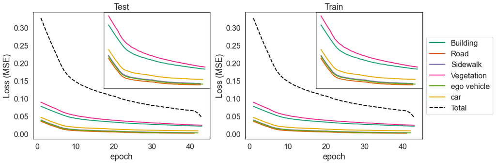

```python
# plot compression ratio and mse for each label
import matplotlib.pyplot as plt
import seaborn as sns
sns.set_theme(style="white", font_scale=1.5, palette='Dark2')
fig, ax = plt.subplots(1,2, figsize=(15,5))
lw=2

from mpl_toolkits.axes_grid1.inset_locator import zoomed_inset_axes
from mpl_toolkits.axes_grid1.inset_locator import mark_inset

# line plots for loss (MSE)
for l in [1,7,8,9,10,100]:
    sns.lineplot(data=all_results_test[all_results_test['label']==l],
                x='epoch', y='loss', ax=ax[0], label=label_name_map[l],
                linewidth=lw)

    sns.lineplot(data=all_results_train[all_results_train['label']==l],
                x='epoch', y='loss', ax=ax[1], label=label_name_map[l],
                linewidth=lw)

# total loss
sns.lineplot(data=total_test_mse,
            x='epoch', y='loss', ax=ax[0], label='Total',
            linewidth=lw, linestyle='--', color='black')

sns.lineplot(data=total_train_mse,
            x='epoch', y='loss', ax=ax[1], label='Total',
            linewidth=lw, linestyle='--', color='black')

inset_ax_0 = ax[0].inset_axes([0.4, 0.4, 0.6, 0.6])
inset_ax_1 = ax[1].inset_axes([0.4, 0.4, 0.6, 0.6])


# line plots for loss (MSE)
for l in [1,7,8,9,10,100]:
    sns.lineplot(data=all_results_test[all_results_test['label']==l],
                x='epoch', y='loss', ax=inset_ax_0, label=label_name_map[l],
                linewidth=lw)
    sns.lineplot(data=all_results_train[all_results_train['label']==l],
            x='epoch', y='loss', ax=inset_ax_1, label=label_name_map[l],
            linewidth=lw)

inset_ax_0.set_xlabel(''), inset_ax_0.set_ylabel('')
inset_ax_0.set_xticklabels([]), inset_ax_0.set_yticklabels([])
inset_ax_1.set_xlabel(''), inset_ax_1.set_ylabel('')
inset_ax_1.set_xticklabels([]), inset_ax_1.set_yticklabels([])
inset_ax_1.legend_.remove()
inset_ax_0.legend_.remove()


#remove legend from fisrt
ax[0].legend_.remove()
ax[1].legend(loc='center left', bbox_to_anchor=(1, 0.5), ncol=1)
ax[0].set_title('Test'), ax[1].set_title('Train')
ax[0].set_ylabel('Loss (MSE)'), ax[1].set_ylabel('Loss (MSE)')
```

```python
# plot best mse vs compression ratio
best_mse = all_results_test.groupby('label')['loss'].min() # for each label
comp_ratio = all_results_test.groupby('label')['compression_ratio'].mean() # for each label

best_performances = pd.DataFrame(columns=['MSE', 'compression_ratio'])
best_performances['compression_ratio'] = comp_ratio
best_performances['MSE'] = best_mse
labels = best_performances.index

# add total loss
total_loss = sum(best_performances['MSE'])
comp_ratio_total = np.mean(best_performances['compression_ratio'])
best_performances = best_performances.append({'MSE': total_loss, 'compression_ratio': comp_ratio_total}, ignore_index=True)
```

```python
labels = labels.append(pd.Index(['Total']))
best_performances.index = labels
```

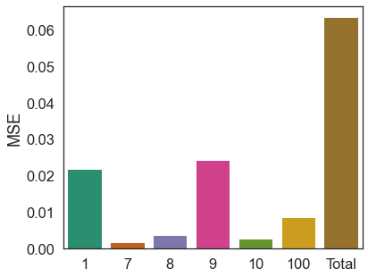

```python
# plot compression ratio and mse for each label
import matplotlib.pyplot as plt
import seaborn as sns

fig, ax  = plt.subplots(1,1, figsize=(6,5))
sns.barplot(x=best_performances.index, y=best_performances['MSE'])
```

## 3D point cloud reconstruction

We decided to compress the points corresponding to labels with high frequency w.r.t the rest of the labels. In particular, we decided to compress the points corresponding to the following labels: road, sidewalk, ego vehicle, building, vegetation, car.

Therefore, in order to reconstruct the 3D point cloud, we do the following:

1. For each of the 6 classes, compress it and reconstruct it using the corresponding autoencoder;
2. Combine the 6 reconstructed point clouds into a single point cloud;
3. Add all the points that belong to the other labels (pedestrian, cyclist, traffic sign, traffic light, etc.) to the reconstructed point cloud.

```python
entirePCPath = '../Town01_Opt_ClearSunset_103317935097620212.ply'
import open3d as o3d
# original PC
original_pc = o3d.io.read_point_cloud(entirePCPath)
```

## Create the ensample of autoencoders

Each autoencoder will take care of a specific class.

Let us now visualize the results of the autoencoders on a sample point cloud.

We apply the proper autoencoder to the point cloud and we visualize the results.

```python
models_paths = 'checkpoints/label_{}/checkpoints/model_39.pth'
autoencoders = dict()
from autoencoder import Autoencoder

for l in [1,7,8,9,10,100]:
    model = Autoencoder()
    model_path = models_paths.format(l)
    # put model in eval mode
    model.load_state_dict(torch.load(model_path))
    model.eval()

    autoencoders[str(l)] = model
```

## Reconstruct the point cloud

```python
original_pc_ply = ply.PlyData.read(entirePCPath)
labels_target = [1,7,8,9,10,100]

all_labels = np.array(original_pc_ply.elements[0].data['ObjTag'])

# start adding all the points that do not belong to the labels that we want to compress
device = torch.device("cuda:0" if torch.cuda.is_available() else "cpu")

all_decoded = []
for lab in labels_target:
    mask = [True if l == lab else False for l in all_labels]
    # create array of points that belong to the label
    plydata = original_pc_ply.elements[0].data[mask]
    # recreate the ply.PlyData
    # plydata = ply.PlyData([ply.PlyElement.describe(plydata, 'vertex')])
    # get only the xyz coordinates
    labtensor = np.vstack([plydata[i].tolist()[:3] for i in range(len(plydata))])
    # print (plydata.shape)
    labtensor = torch.from_numpy(labtensor).float()
    # reshape column number must be channel number
    labtensor = labtensor.view( 1, labtensor.shape[1], labtensor.shape[0])

    model = autoencoders[str(lab)]
    model.eval()
    model = model.to(device)

    encoded, decoded =  model(labtensor.to(device))

    # change shape again
    decoded = decoded.view(decoded.shape[2], decoded.shape[1])

    decoded = decoded.cpu().detach().numpy()

    print (decoded.shape)
    all_decoded.append(decoded)

# go bach to 8957x3
all_decoded = np.vstack(all_decoded)
all_decoded = all_decoded.reshape(-1,3)

#save the decoded points
print (all_decoded.shape)
np.savetxt('decoded_points.txt', all_decoded)
```

```
(8957, 3)
(91912, 3)
(46847, 3)
(22724, 3)
(46885, 3)
(2726, 3)
(220051, 3)
```

### Visualize the reconstructed point cloud

```python
original_pc_ply = ply.PlyData.read(entirePCPath)
labels_target = [1,7,8,9,10,100]

all_labels = np.array(original_pc_ply.elements[0].data['ObjTag'])
# remove all target labels
mask = [True if l not in labels_target else False for l in all_labels]
# create array of points that belong to the label
plydata = original_pc_ply.elements[0].data[mask]
plydata = np.vstack([plydata[i].tolist()[:3] for i in range(len(plydata))])

# add the decoded points
plydata = np.vstack([plydata, all_decoded])

# decoded_pc = np.vstack([all_decoded, original_pc_ply.elements[0].data])
```

```python
#create point cloud
decoded_pc = o3d.geometry.PointCloud()
decoded_pc.points = o3d.utility.Vector3dVector(plydata)

# visualize
o3d.visualization.draw_geometries([decoded_pc])
```

Some screenshots of the reconstructed point cloud are shown here.

[figure not shown]

### Visualize the original point cloud

```python
original_pc = o3d.io.read_point_cloud(entirePCPath)

# visualize
o3d.visualization.draw_geometries([original_pc])
```

Some screenshots of the original point cloud are shown here.

[figure not shown]

As we can see , we are able to reconstruct the main features of the point cloud. However, we can see that the reconstruction is not perfect. In particular, we can see that the reconstructed point cloud is not as dense as the original point cloud.

In order to improve the reconstruction, we can use a more complex architecture. Moreover, we can also use a more complex loss function. In fact, we are using the MSE loss function. However, we can use a more complex loss function such as the Chamfer distance.

# Visualize the original point cloud

# Projection of 3D points into 2D image plane

2) Define a 2D grid for the angles $\theta$, $\phi$ by assigning a value of 'pixel size' (e.g. 1 degree) and a range of values for $\theta$ and $\phi$ (e.g. $\theta \in [-\pi/2, \pi/2]$ and $\phi \in [0, 2\pi]$).

3) for each pixel defined in the grid, assign the value $r$ of the 3D point $P$ that is closest to the pixel center.

4) The obtained 2D images looses the depth information, of points hidden behind the closest surface, but we assume that in an autonomous driving scenario, the most important information is the distance to the closest obstacle.

Note that, in order to reduce the loss of points behind the closest surface, it is still possible to define a quantization in the radius. In this way we wouls end up with a series of surfaces, each of which refers to a different layer of distance from the observer

```python
import numpy as np
import matplotlib.pyplot as plt
import seaborn as sns
import os
import open3d as o3d
from pyntcloud import PyntCloud
import glob
import plyfile as ply
from tqdm import tqdm
import pandas as pd
```

```python
# pixel sizes on which we want to compress the point cloud (in degrees)
pixel_sizes = [(1,1), (2,2), (5,5)]

# create the corresponding folders
main_out_dir = "2DRepresentation"
out_dirs = [os.path.join(main_out_dir, str(pixel_size[0]) + "_" + str(pixel_size[1])) for pixel_size in pixel_sizes]
for out_dir in out_dirs:
    if not os.path.exists(out_dir):
        os.makedirs(out_dir)
```

```python
# take all top lidars and convert them into images
main_dir = "dataset-downloader-kit/CV/dataset/Town01_Opt_ClearSunset/LIDAR_TOP"
N_point_clouds = 10

# get all the files in the directory
files = np.sort(glob.glob(main_dir + "/*.ply"))
files = files[:5*N_point_clouds]
```

```python
def get_labels (path, save=False):
    plydata = ply.PlyData.read(path)
    labels = np.array(plydata.elements[0].data['ObjTag'])
    if save:
        np.save(path.split('.')[0] + '_labels.npy', labels)
    return labels

def get_images (
    path: str,
    theta_range:tuple = (-np.pi/4, np.pi/4),
    phi_range:tuple = (0, 2*np.pi),
    pixel_size:tuple = (2, 2),
    stepR:int= None,
    ):
    """
    path: path to the ply file
    theta_range: range of theta to consider
    phi_range: range of phi to consider
    pixel_size: size of the pixel in degrees

    returns:
    dictionary with
        - key: label of the object
        - value: 2d representation of the object
    """
    # load point cloud and labels
    pc = o3d.io.read_point_cloud(path, format='ply')
    labels = get_labels(path)
    all_points = np.asarray(pc.points)
    x, y, z = all_points[:, 0], all_points[:, 1], all_points[:, 2]

    # get spherical coordinates
    r = np.sqrt(x**2 + y**2 + z**2)

    # theta = np.zeros(len(x))
    theta =  np.arctan(z , np.sqrt(x**2 + y**2)) # -pi/2, pi/2

    # we want a 360 range phi
    phi = np.zeros(len(x))
    mask = np.logical_and (x >= 0, y >= 0)
    xs = x[mask]
    ys = y[mask]
    phi[mask] = np.arctan(ys, xs) # ranges 0, pi/2

    mask = x < 0
    xs = x[mask]
    ys = y[mask]
    phi[mask] = np.arctan(ys, xs) + np.pi # ranges pi/2, pi

    mask = np.logical_and (x>=0, y < 0)
    xs = x[mask]
    ys = y[mask]
    phi[mask] = np.arctan(ys, xs) + 2*np.pi # ranges pi, 3pi/2


    # define the grid
    pixel_size_rad = (np.deg2rad(pixel_size[0]), np.deg2rad(pixel_size[1]))

    phi_grid = np.arange(phi_range[0], phi_range[1]+1, pixel_size_rad[0])

    theta_grid = np.arange(theta_range[0], theta_range[1]+1, pixel_size_rad[1])

    # get all the labels and image
    all_labels = np.unique(labels)

    result = dict()

    for l in all_labels:
        lmask = labels == l


        rs_class = r[lmask]

        if stepR is not None:
            rs_pixels_min = np.min(rs_class)
            rs_pixels_max = np.max(rs_class)
            step_size_r = (rs_pixels_max - rs_pixels_min)/stepR
            rs_pixel_bounds = [rs_pixels_min + i*step_size_r for i in range(stepR+1)]

            result[l] = dict ()

            for k, r_min in enumerate(rs_pixel_bounds):
                img = np.zeros((len(phi_grid), len(theta_grid)))
                for i, ph in enumerate(phi_grid):
                    for j, th in enumerate(theta_grid):

                        tmask = np.logical_and(theta>=th, theta<th+pixel_size[1])
                        pmask = np.logical_and(phi>=ph, phi<ph+pixel_size[0])

                        rs_pixel = r[tmask & pmask & lmask]


                        if len(rs_pixel) > 0:
                            # print (f"pixel {i,j} has {len(rs_pixel)} points, min distance {np.min(rs_pixel)}")
                            min_index = np.argmin(rs_pixel)

                            img[i,j] = rs_pixel[min_index]
                result[l]["r_min_%d"%k] = img
        else:
            img = np.zeros((len(phi_grid), len(theta_grid)))
            for i, ph in enumerate(phi_grid):
                for j, th in enumerate(theta_grid):

                    tmask = np.logical_and(theta>=th, theta<th+pixel_size[1])
                    pmask = np.logical_and(phi>=ph, phi<ph+pixel_size[0])

                    rs_pixel = r[tmask & pmask & lmask]


                    if len(rs_pixel) > 0:
                        # print (f"pixel {i,j} has {len(rs_pixel)} points, min distance {np.min(rs_pixel)}")
                        min_index = np.argmin(rs_pixel)

                        img[i,j] = rs_pixel[min_index]
            result[l] = img
    return result
```

## No distance quantization

In this case we assume that the radius is not quantized, so we have a panoramic at one layer for each run. In particular, we project the 3D points into a 2D image for each class, this allows to reduce the loss of information due to the non quantization of the radius.

To sum up, we follow the following steps:

1) For each class, select the points belonging to the class and project them into a 2D image. We obtain a set of 2D images for each point cloud, each of which represents the closest surface for each class.

2) Each image can be compressed by means of any image compression algorithm (e.g. JPEG, PNG, etc.) and stored in a file.

3) By knowing the grid quantization of angles $\theta$, $\phi$ and the radius, it is possible to reconstruct the 3D point cloud from the 2D images.

We repeat these steps for each point cloud, with 3 different pixel quantizations: 1 degree, 2 degrees and 5 degrees, for both the angles $\theta$, $\phi$ .

```python
# let us run a test without radius grid
step_radius = None
pixel_sizes = [(1,1,), (2,2), (5,5,)]

for ps, od in zip(pixel_sizes, out_dirs):
    print ("Processing pixel size: ", ps)
    for f in tqdm(files):
        # image name
        image_name = f.split("/")[-1].split(".")[0]

        # dictionary of key-value pairs: key is the label, value is the image itself
        im = get_images (
            path=f,
            theta_range=(-np.pi/4, np.pi/4),
            phi_range=(0, 2*np.pi),
            pixel_size=ps,
            stepR=step_radius
            )
        save_folder = os.path.join(od, f"{image_name}")

        if not os.path.exists(save_folder):
            os.makedirs(save_folder)

        for k, v in im.items():
            # save txt file
            np.savetxt(os.path.join(save_folder, f"{image_name}_{k}.txt"), v, fmt="%d")
```

#### Visualization of the 2D images

Let us visualize the 2D images obtained for the 3 different pixel quantizations for the same point cloud.

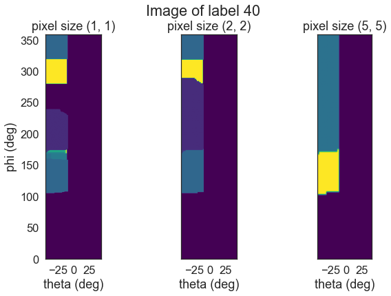

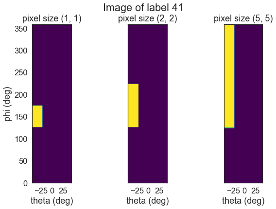

[figure not shown]

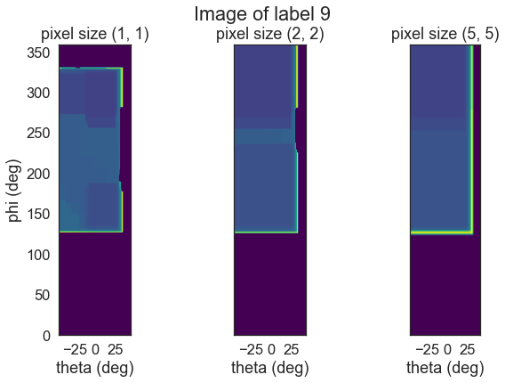

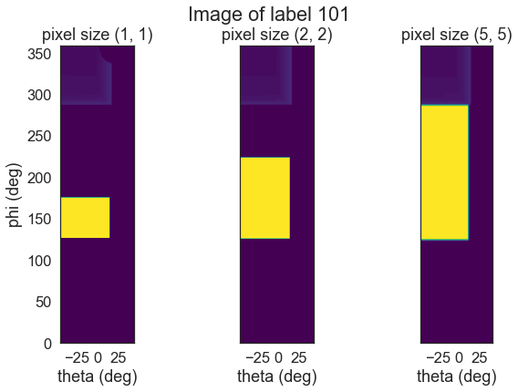

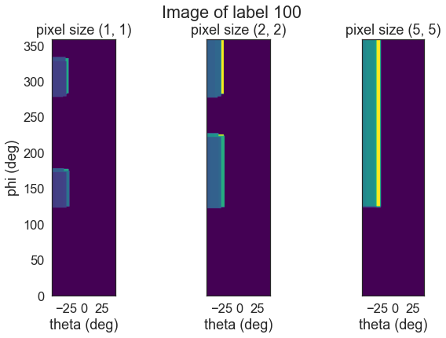

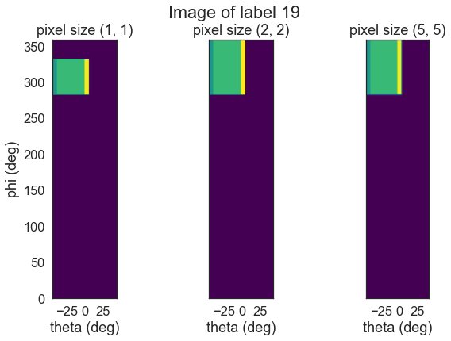

[figure not shown]

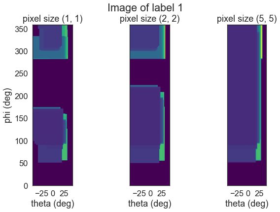

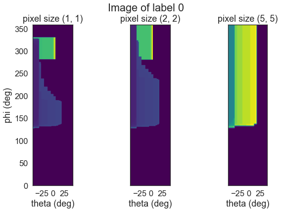

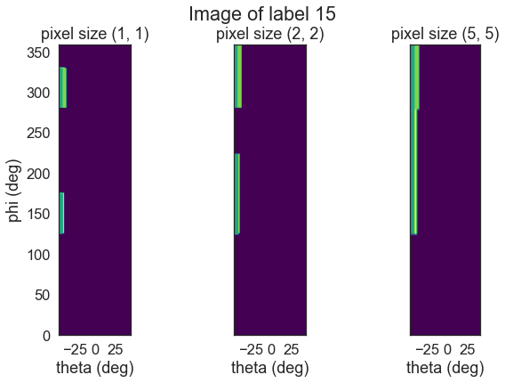

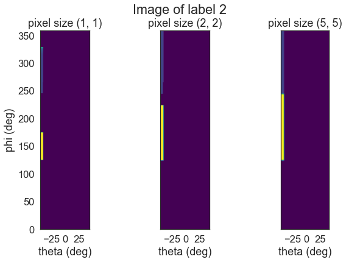

[4 more figures not shown]

```python
pc_name = "Town01_Opt_ClearSunset_103317935097620212"
pixel_sizes = [(1,1,), (2,2), (5,5,)]

reduced_images_path = "2DRepresentation/1_1/"+pc_name+"/"+pc_name+"_*.txt"
labels_img = glob.glob(reduced_images_path)
labels_img = [int(l.split("/")[-1].split("_")[-1].split(".")[0]) for l in labels_img]

sns.set_theme(font_scale=1.5, palette="mako", style="white")

for ll in labels_img:
    fig, ax = plt.subplots(1,3,figsize=(10, 6))
    for i, ps in enumerate(pixel_sizes):
        rad_pixel = np.deg2rad(ps[0])
        phi_grid = np.arange(0, 2*np.pi, rad_pixel)
        theta_grid = np.arange(-np.pi/4, np.pi/4, rad_pixel)
        reduced_images_path =  "2DRepresentation/"+f"{ps[0]}_{ps[1]}/{pc_name}/{pc_name}_{ll}.txt"
        img = np.loadtxt(reduced_images_path)
        ax[i].imshow(img, cmap="viridis",
        extent=[np.rad2deg(theta_grid[0]), np.rad2deg(theta_grid[-1]), np.rad2deg(phi_grid[0]), np.rad2deg(phi_grid[-1])])
        ax[i].set_title(f"pixel size {ps}")

        if i == 0: ax[i].set_ylabel("phi (deg)")
        if i != 0:
            ax[i].set_yticklabels([])

        ax[i].set_xlabel("theta (deg)")

    fig.suptitle(f"Image of label {ll}")
    plt.show()
```

```python
def LZW_encoder (input_file, n):
    from struct import pack

    maximum_table_size = pow(2,int(n))
    file = open(input_file)
    data = file.read()

    # Building and initializing the dictionary.
    dictionary_size = 256
    dictionary = {chr(i): i for i in range(dictionary_size)}
    string = ""             # String is null.
    compressed_data = []    # variable to store the compressed data.

    # iterating through the input symbols.
    # LZW Compression algorithm
    for symbol in data:
        string_plus_symbol = string + symbol # get input symbol.
        if string_plus_symbol in dictionary:
            string = string_plus_symbol
        else:
            compressed_data.append(dictionary[string])
            if(len(dictionary) <= maximum_table_size):
                dictionary[string_plus_symbol] = dictionary_size
                dictionary_size += 1
            string = symbol

    if string in dictionary:
        compressed_data.append(dictionary[string])

    # storing the compressed string into a file (byte-wise).
    out = 'LZW/' + input_file.split(".")[0]
    path = os.path.dirname(out)
    if not os.path.exists(path):
        os.makedirs(path)

    output_file = open(out + ".lzw", "wb")
    for d in compressed_data:
        output_file.write(pack('>H',int(d)))

    output_file.close()
    file.close()

    results = {
        "input_file": input_file,
        "output_file": out + ".lzw",
        "compression_ratio_%": 100*(1 - len(compressed_data)/len(data)),
        'compressed_data': compressed_data,
    }
    return results

def LZW_decoder (input_file, n):
    from struct import unpack

    maximum_table_size = pow(2,int(n))
    file = open(input_file, "rb")
    compressed_data = []
    next_code = 256
    decompressed_data = ""
    string = ""

    # Reading the compressed file.
    while True:
        rec = file.read(2)
        if len(rec) != 2:
            break
        (data, ) = unpack('>H', rec)
        compressed_data.append(data)

    # Building and initializing the dictionary.
    dictionary_size = 256
    dictionary = dict([(x, chr(x)) for x in range(dictionary_size)])

    # iterating through the codes.
    # LZW Decompression algorithm
    for code in compressed_data:
        if not (code in dictionary):
            dictionary[code] = string + (string[0])
        decompressed_data += dictionary[code]
        if not(len(string) == 0):
            dictionary[next_code] = string + (dictionary[code][0])
            next_code += 1
        string = dictionary[code]

    # storing the decompressed string into a file.
    out = 'LZW/' + input_file.split(".")[0]
    path = os.path.dirname(out)
    if not os.path.exists(path):
        os.makedirs(path)

    output_file = open(out + "_decoded.txt", "w")
    decompressed = []

    for data in decompressed_data:
        output_file.write(data)

    output_file.close()
    file.close()


    result = {
        "input_file": input_file,
        "output_file": out + "_decoded.txt",
        "decompressed_data": decompressed,
    }
    return result
```

```python
# LZW compression for an example image


bits_compression = [6, 8, 10, 12]
compression_results = pd.DataFrame(columns=[ "compression_ratio_%", "label", "bits", "pixel_size"])

pc_name = "Town01_Opt_ClearSunset_103317935097620212"
pixel_sizes = [(1,1,), (2,2), (5,5,)]

reduced_images_path = "2DRepresentation/1_1/"+pc_name+"/"+pc_name+"_*.txt"
labels_img = glob.glob(reduced_images_path)
labels_img = [int(l.split("/")[-1].split("_")[-1].split(".")[0]) for l in labels_img]

sns.set_theme(font_scale=1.5, palette="mako", style="white")


for b in bits_compression:
    for ps in pixel_sizes:
        for cl in labels_img:
            reduced_images_path =  "2DRepresentation/"+f"{ps[0]}_{ps[1]}/{pc_name}/{pc_name}_{ll}.txt"

            r = LZW_encoder(reduced_images_path, b)
            d = LZW_decoder(r["output_file"], b)

            original_data = np.loadtxt(reduced_images_path)
            decompressed = np.loadtxt(d["output_file"])

            # check if the original data is equal to the decompressed data
            MSE = np.mean((original_data - decompressed)**2)
            # should be zero because its lossless compression
            compression_results = compression_results.append({
                "compression_ratio_%": r["compression_ratio_%"],
                "label": cl,
                "bits": b,
                "pixel_size": ps,
            }, ignore_index=True)

# save the results
compression_results.to_csv("results/LWZcompression_stats.csv", index=False)
```

```python
compression_results = pd.read_csv("results/LWZcompression_stats.csv")

compression_results = compression_results.astype({"label": int, "bits": int, "pixel_size": str})
compression_results["pixel_size"] = compression_results["pixel_size"].apply(lambda x: int(x[1]))
compression_results
```

|  | compression_ratio_% | label | bits | pixel_size |
| --- | --- | --- | --- | --- |
| 0 | 0.000000 | 40 | 6 | 1 |
| 1 | 0.000000 | 41 | 6 | 1 |
| 2 | 0.000000 | 8 | 6 | 1 |
| 3 | 0.000000 | 9 | 6 | 1 |
| 4 | 0.000000 | 101 | 6 | 1 |
| ... | ... | ... | ... | ... |
| 187 | 92.102226 | 2 | 12 | 5 |
| 188 | 92.102226 | 10 | 12 | 5 |
| 189 | 92.102226 | 7 | 12 | 5 |
| 190 | 92.102226 | 11 | 12 | 5 |
| 191 | 92.102226 | 5 | 12 | 5 |

192 rows × 4 columns

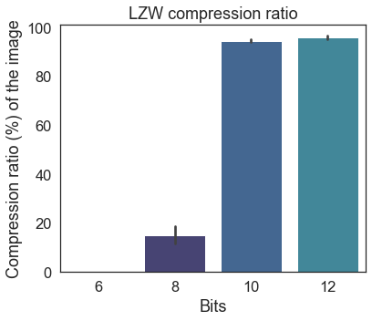

```python
fig, ax = plt.subplots(figsize=(6, 5))
sns.barplot(data=compression_results, x="bits", y="compression_ratio_%", ax=ax)
ax.set_title("LZW compression ratio")
ax.set_xlabel("Bits")
ax.set_ylabel("Compression ratio (%) of the image")
```

### Reconstruction of the 3D point cloud

Finally, we can reconstruct the 3d point cloud from the 2D images by means of an inverse mapping (sphere to cartesian coordinates).

```python
def reconstruct_3D(
        path_to_2d,
        pixel_size = (2,2),
        theta_range = (-np.pi/4, np.pi/4),
        phi_range = (0, 2*np.pi),
        save=False,
        save_path='reconstructed_PC'
        ):
    """
    path_to_2d: path to the 2d representation of the point cloud
    theta_range: range of theta to consider
    phi_range: range of phi to consider
    pixel_size: size of the pixel in degrees
    save: if true, saves the point cloud as a ply file
    """

    img = np.loadtxt(path_to_2d)

    pixel_size_rad = (np.deg2rad(pixel_size[0]), np.deg2rad(pixel_size[1]))

    phi_grid = [phi_range[0] + i*pixel_size_rad[0] for i in range(img.shape[0])]

    theta_grid = [theta_range[0] + i*pixel_size_rad[1] for i in range(img.shape[1])]


    cartesian_coordinates = []

    # theta ranges -pi/4 to pi/4
    # phi ranges 0 to 2pi, but the backward mapping is not the one of standard spherical coordinates
    # in the forward mapping we did:
    # x>0, y>0 -> phi = 0, phi/2
    # x<0 -> phi = pi/2, pi -> which corresponds to adding pi to the phi obtained from the backward mapping
    # y<0 -> phi = 3pi/2, 2pi -> which corresponds to adding 2pi to the phi obtained from the backward mapping

    # check length of img and phi_grid

    for i, phi in enumerate(phi_grid):
        for j, theta in enumerate(theta_grid):
            r = img[i,j]

            if r == 0: continue

            # # when phi is in 0, pi/2, x>0, y>0
            # if phi < np.pi/2:
            #     phi = phi
            # # when phi is in pi/2, pi, x<0, y>0
            # elif phi < np.pi and phi >= np.pi/2:
            #     phi = phi - np.pi
            # # when phi is in pi, 3pi/2, x<0, y<0
            # elif phi < 3*np.pi/2 and phi >= np.pi:
            #     phi = phi - 2*np.pi

            x = r*np.cos(theta)*np.cos(phi)
            y = r*np.cos(theta)*np.sin(phi)
            z = r*np.sin(theta)
            # print (x, y, z, r , theta, phi, sintheta)

            cartesian_coordinates.append([x, y, z])
    pcd = o3d.geometry.PointCloud()
    pcd.points = o3d.utility.Vector3dVector(cartesian_coordinates)
    if save:
        if not os.path.exists(save_path):
            os.makedirs(save_path)

        o3d.io.write_point_cloud( os.path.join(save_path, path_to_2d.split('/')[-1].split('.')[0] + '.ply'), pcd)
    return pcd
```

Let us consider the following example, in which we assign a random color to each class.

```
class 9, pixel size 1
class 100, pixel size 1
class 9, pixel size 2
class 100, pixel size 2
class 9, pixel size 5
class 100, pixel size 5
```

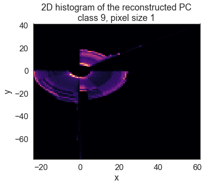

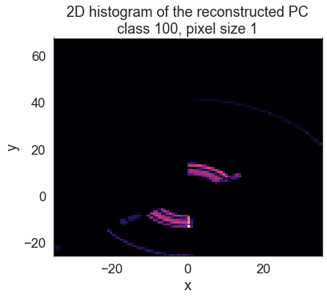

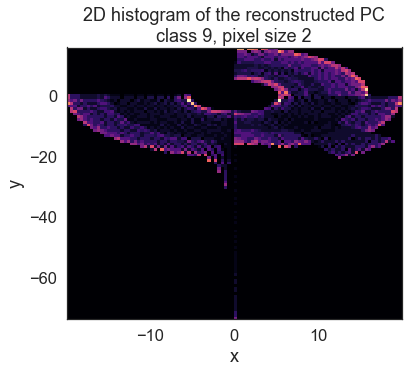

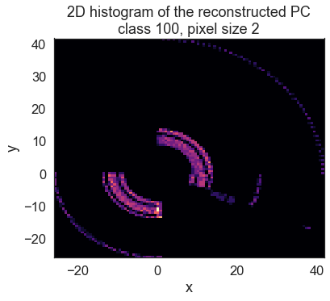

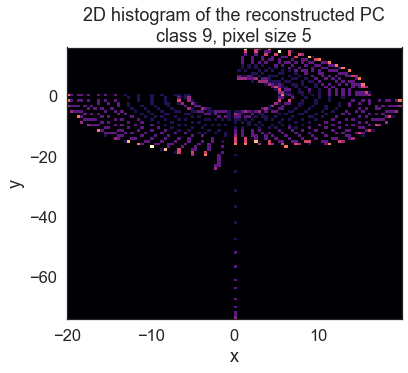

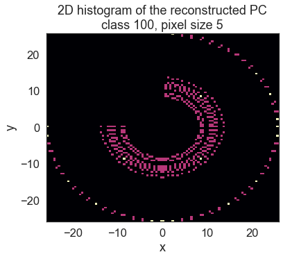

```python
pc_name = "Town01_Opt_ClearSunset_103317935097620212"
reduced_images_path = "2DRepresentation/1_1/"+pc_name+"/"+pc_name+"_*.txt"
# labels_img = glob.glob(reduced_images_path)
# labels_img = np.unique([int(l.split("/")[-1].split("_")[-1].split(".")[0]) for l in labels_img])
labels_img = [9, 100]
pixel_sizes = [1,2,5]

point_clouds = dict()

for p in pixel_sizes:

    # reconstructed point cloud
    pc = o3d.geometry.PointCloud()

    # different color for each class
    colors = dict()
    for i, cl in enumerate(labels_img):
        colors[cl] = np.random.rand(3)

    for cl in labels_img:
        reduced_images_path =  "2DRepresentation/"+f"{p}_{p}/{pc_name}/{pc_name}_{cl}.txt"

        print (f"class {cl}, pixel size {p}")

        pcd, ax = reconstruct_3D(
            reduced_images_path,
            theta_range=(-np.pi/4, np.pi/4),
            phi_range=(0, 2*np.pi),
            pixel_size = (p,p),
        )
        ax.set_title(f"2D histogram of the reconstructed PC\nclass {cl}, pixel size {p}")
        # assign the color to the point cloud, a different color for each class
        pcd.paint_uniform_color(colors[cl])
        pc += pcd

    point_clouds[p] = pc

# save the point clouds
reconstructed_path = f"results/point_clouds_reconstructed"
if not os.path.exists(reconstructed_path):
    os.makedirs(reconstructed_path)

for p in pixel_sizes:
    o3d.io.write_point_cloud( os.path.join(reconstructed_path, f"{pc_name}_{p}.ply"), point_clouds[p])
```

To conclude, the model should be enriched with a better 2D representation of the point cloud, in order to reduce the loss of information due to the projection of the 3D points into a 2D image plane.

Main issues:

- We loose the information about depth;
- Good pixelization needs large computation time.

Future works:

- Explore a better 2D representation;
- Add a quantization on depth.

References:

[1] *SELMA: SEmantic Large-scale Multimodal Acquisitions in Variable Weather, Daytime and Viewpoints*, Testolina, Paolo and Barbato, Francesco and U. Michieli, M. Giordani and P. Zanuttigh and M. Zorzi, 2022

[2] F. Nardo, D. Peressoni, P. Testolina, M. Giordani, and A. Zanella, “Point cloud compression for efficient data broadcasting: A performance comparison,” IEEE Wireless Communications and Networking Conference (WCNC), Austin, USA, 2022.

[3] Tu, Chenxi & Takeuchi, Eijiro & Carballo, Alexander & Takeda, Kazuya. (2019). Point Cloud Compression for 3D LiDAR Sensor using Recurrent Neural Network with Residual Blocks. 10.1109/ICRA.2019.8794264.